# Crack Detection for Buidlings Data Preparation

MRR- Denitsa Goranova and Anna Kadurina

## Introduction

[figure not shown]

In this notebook, we are going to investigate crack in various surfices. Crack detection is significant in maintenance of concrete facilities. For this reason, we want to develop a model which with the help of drone pictures as input and pretrained dataset, is going to detect crack in buldings. There is one issue which is cruical for this project which is dataset availability. The perfect dataset would contain drone pictures from different angles and handhled images for cracks, pictured in different light conditions, angles and backgroudns. The goal of this notebook is to determine if there is an online source for a dataset that is going to be useful for the Crack Detection goal that our group project has.

## Domain Understaning

We want to develop an automated deep learning model which will accurately detect cracks in building images which are gathered from a drone mission. We want to have it so we can use real-world variatoins in environmental conditions. The model will check diffferent type of cracks in various surfaces.

## Loading libraries

The first part that we need in order to achieve this is to load the required libraries.

```python
import os
import random
import numpy as np
import tensorflow as tf
import pandas as pd
import seaborn as sns
import matplotlib.pyplot as plt
from PIL import Image
import cv2
from sklearn.preprocessing import MinMaxScaler
from sklearn.model_selection import train_test_split
from sklearn.metrics import confusion_matrix, classification_report, ConfusionMatrixDisplay
from imblearn.over_sampling import SMOTE
from tensorflow.keras.preprocessing.image import load_img, img_to_array, ImageDataGenerator, save_img
from tensorflow.keras.models import Sequential
from tensorflow.keras.layers import Dense, Dropout, BatchNormalization, Add
from tensorflow.keras.optimizers import Adam
from tensorflow.keras import layers, models
from tensorflow.keras.applications import VGG16
from tensorflow.keras.optimizers import Adam, RMSprop, SGD
print("TensorFlow Version:", tf.__version__)
```

```
WARNING:tensorflow:From C:\Users\anika\AppData\Local\Packages\PythonSoftwareFoundation.Python.3.11_qbz5n2kfra8p0\LocalCache\local-packages\Python311\site-packages\keras\src\losses.py:2976: The name tf.losses.sparse_softmax_cross_entropy is deprecated. Please use tf.compat.v1.losses.sparse_softmax_cr…

TensorFlow Version: 2.15.0
```

## Data Provisioning

### Data Requirements

To begin with this interesting journey we will need some relevant data with cracks. The dataset needs to contain categorized images in two classes: cracked and non-cracked surfaces.

#### Data Elements

```
- Image of cracks on different surfices
- Labels of images- positive or negative(cracked or not cracked)
- Image type: JPEG,PNG
- Dimensions: can vary
```

### Data Volume

The estimated data colume that we would need for this project can be between 40 000 and 100 000. It should be balanced per class. We would need so much data because of the different surfaces, lights, angles and the models will need as much data as possible.

### Data Quality Standards

To ensure the usability of the dataset, we should have the following standards:

- Accuracy
  - Each image should be correctly labeled
  - Remove duplicate values or mislabeled data
- Consistency
  - Standardize image formats and resolution
  - Balanced dataset
- Completeness
  - No missing or incomplete labels
- Image Quality
  - The images should be clear(no blurry images)

# Data Collection

### Data Source

For gathering data, I decided I will be using Kaggle, which is the world's largest data community. This is the link for my main data set which is the Building Cracks Dataset https://www.kaggle.com/datasets/gargeekate/building-cracks , which is updated 3 years ago. This dataset contains 40 000 results(20 000 cracked ones and 20 000 non- cracked ).

## Sample the data

Now, we are going to load the dataset and visualize it so we can get a quick first look of the dataset.

```python
positive_path = "cracksPavements/Positive"
negative_path = "cracksPavements/Negative"

positive_images = os.listdir(positive_path)
negative_images = os.listdir(negative_path)

image_paths = []
labels = []

for image_name in positive_images:
    image_path = os.path.join(positive_path, image_name)
    image_paths.append(image_path)
    labels.append(1)

for image_name in negative_images:
    image_path = os.path.join(negative_path, image_name)
    image_paths.append(image_path)
    labels.append(0)

img = Image.open(image_paths[0])
img.show()

print("Sample image paths and labels:")
for i in range(5):
    print(f"Image Path: {image_paths[i]} | Label: {labels[i]}")
```

```
Sample image paths and labels:
Image Path: cracksPavements/Positive\00001.jpg | Label: 1
Image Path: cracksPavements/Positive\00002.jpg | Label: 1
Image Path: cracksPavements/Positive\00003.jpg | Label: 1
Image Path: cracksPavements/Positive\00004.jpg | Label: 1
Image Path: cracksPavements/Positive\00005.jpg | Label: 1
```

## Data Unerstanding

In this section I will discover more about the dataframes and the realtionships. I am going to start with checking how many results we have in both of the folders.

We are now going to verify the image properties before actually processing it, we need to ensure consitency and also check the color of the images.

```python
all_image_paths = [
    os.path.join(positive_path, img) for img in os.listdir(positive_path)
] + [
    os.path.join(negative_path, img) for img in os.listdir(negative_path)
]

image_properties = {}

for img_path in all_image_paths:
    try:
        with Image.open(img_path) as img:
            img_format = img.format
            img_size = img.size
            img_mode = img.mode

            key = (img_format, img_size, img_mode)
            if key in image_properties:
                image_properties[key] += 1
            else:
                image_properties[key] = 1

    except Exception as e:
        print(f"Error loading image {img_path}: {e}")
for props, count in image_properties.items():
    print(f"Format: {props[0]}, Size: {props[1]}, Mode: {props[2]} - {count} images")
```

```
Format: JPEG, Size: (227, 227), Mode: RGB - 40000 images
```

Both of the datasets are in JPEG format, so we will not need format standardization. THe images are in size 227,227 pixels, which is very convenient for deep learning models since they are in a square figure. The mode of the image is RGB and in other words it has color(Red, green and blue), which is also good for our project because if they were in L mode , they might need conversion.

I also want to take a look at a random picture from both classes. We can see that the images are taken from a very close angle but they haev a very good light.

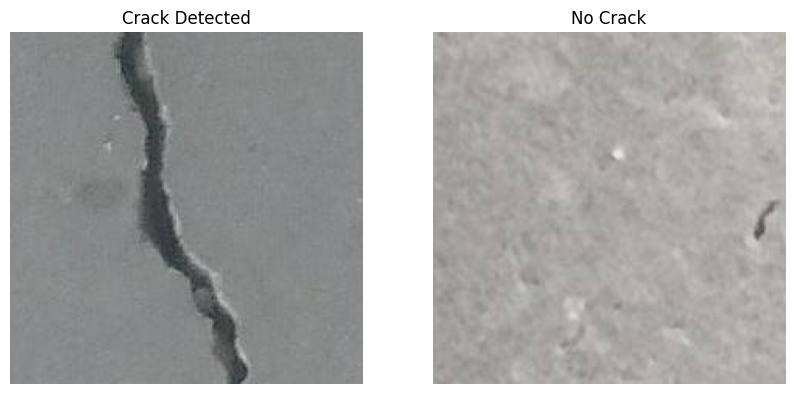

```python
fig, axes = plt.subplots(1, 2, figsize=(10, 5))

pos_img = Image.open(os.path.join(positive_path, os.listdir(positive_path)[0]))
axes[0].imshow(pos_img)
axes[0].set_title("Crack Detected")

neg_img = Image.open(os.path.join(negative_path, os.listdir(negative_path)[0]))
axes[1].imshow(neg_img)
axes[1].set_title("No Crack")

for ax in axes:
    ax.axis("off")

plt.show()
```

Now let's check how many results we have for cracked and no-cracked images.

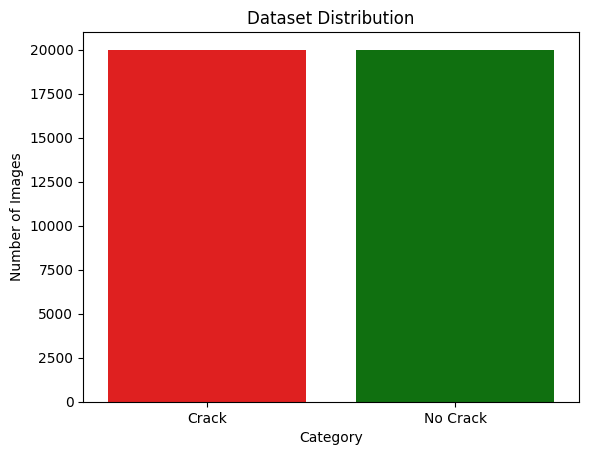

```python
num_positive = len(os.listdir(positive_path))
num_negative = len(os.listdir(negative_path))

data = {"Category": ["Crack", "No Crack"], "Count": [num_positive, num_negative]}

sns.barplot(x=data["Category"], y=data["Count"], palette=["red", "green"])
plt.xlabel("Category")
plt.ylabel("Number of Images")
plt.title("Dataset Distribution")
plt.show()
```

The good this is our dataset is balanced(20 000 cracked and 20 000 noncraked).

Becuase our dataset is large it would be nice to have a smaller dataset so we can work quicker and easier at least for the EDA part. I decided I would use 2500 from both the classes and I will shuffle them so they are randomly distributed.

```python
num_samples = 5000

positive_sample = random.sample(positive_images, num_samples // 2)
negative_sample = random.sample(negative_images, num_samples // 2)

image_paths = []
labels = []

for image_name in positive_sample:
    image_paths.append(os.path.join(positive_path, image_name))
    labels.append(1)

for image_name in negative_sample:
    image_paths.append(os.path.join(negative_path, image_name))
    labels.append(0)

combined = list(zip(image_paths, labels))
random.shuffle(combined)
image_paths, labels = zip(*combined)

print(f"Dataset size after sampling: {len(image_paths)}")
```

```
Dataset size after sampling: 5000
```

## Data Preparation

This part is focused on converting the dataframe into a fomrat suitable for the model to be trained and afterwards evaluated. We are going to normalize the pixels of the images, remove duplicated and check for empty values. The dataset will also be converted into train and test data. Upon inspection, our dataset was relatively clean and well- structred. There was no missing data or corrupted images. All of the images were labeled, the image resolutiion were high. There were no significant duplications. This is allowing us to move efficiently into the preprocesssing and transofmation steps.

### PreProcessing

In order to use the dataset, we need to resize, normalize and convert them. We will resize them in 128x128 picxels, convert them into an array and normalize them into pixels so we can improve training stability.

#### Resize and normalize images

```python
def preprocess_image(image_path, target_size=(128, 128)):
    img = load_img(image_path, target_size=target_size)
    img = img_to_array(img)
    img = img / 255.0
    return img

processed_images = np.array([preprocess_image(img_path) for img_path in image_paths], dtype=np.float32)
labels = np.array(labels)
```

Now, let's see a sample of the preprocessed images both with cracks and without.

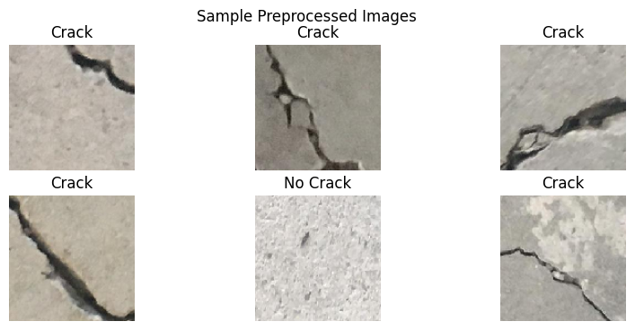

```python
plt.figure(figsize=(10, 4))
for i in range(6):
    plt.subplot(2, 3, i+1)
    plt.imshow(processed_images[i])
    plt.axis('off')
    plt.title("Crack" if labels[i] == 1 else "No Crack")
plt.suptitle("Sample Preprocessed Images")
plt.show()
```

Lastly, we need to split the data into training and test set.

```python
X_train, X_val, y_train, y_val = train_test_split(processed_images, labels, test_size=0.2, random_state=42)

print(f"Training data shape: {X_train.shape}")
print(f"Validation data shape: {X_val.shape}")

train_dataset = tf.data.Dataset.from_tensor_slices((X_train, y_train))
val_dataset = tf.data.Dataset.from_tensor_slices((X_val, y_val))

train_dataset = train_dataset.shuffle(buffer_size=1000).batch(32).prefetch(tf.data.experimental.AUTOTUNE)
val_dataset = val_dataset.batch(32).prefetch(tf.data.experimental.AUTOTUNE)
```

```
Training data shape: (4000, 128, 128, 3)
Validation data shape: (1000, 128, 128, 3)
```

### CNN

We are creating a custom CNN to see if the dataset has potential to work for our problem.

```python
def build_cnn_model(input_shape=(128, 128, 3)):
    model0 = models.Sequential()
    model0.add(layers.Conv2D(32, (3, 3), activation='relu', input_shape=input_shape))
    model0.add(layers.MaxPooling2D((2, 2)))
    model0.add(layers.Conv2D(64, (3, 3), activation='relu'))
    model0.add(layers.MaxPooling2D((2, 2)))
    model0.add(layers.Conv2D(128, (3, 3), activation='relu'))
    model0.add(layers.MaxPooling2D((2, 2)))
    model0.add(layers.Flatten())
    model0.add(layers.Dense(128, activation='relu'))
    model0.add(layers.Dropout(0.5))
    model0.add(layers.Dense(1, activation='sigmoid'))

    model0.compile(optimizer='adam', loss='binary_crossentropy', metrics=['accuracy'])
    return model0

model0 = build_cnn_model(input_shape=(128, 128, 3))

model0.summary()
```

```
WARNING:tensorflow:From C:\Users\anika\AppData\Local\Packages\PythonSoftwareFoundation.Python.3.11_qbz5n2kfra8p0\LocalCache\local-packages\Python311\site-packages\keras\src\backend.py:873: The name tf.get_default_graph is deprecated. Please use tf.compat.v1.get_default_graph instead.

WARNING:tensorflow:From C:\Users\anika\AppData\Local\Packages\PythonSoftwareFoundation.Python.3.11_qbz5n2kfra8p0\LocalCache\local-packages\Python311\site-packages\keras\src\layers\pooling\max_pooling2d.py:161: The name tf.nn.max_pool is deprecated. Please use tf.nn.max_pool2d instead.

WARNING:tensorflow:From C:\Users\anika\AppData\Local\Packages\PythonSoftwareFoundation.Python.3.11_qbz5n2kfra8p0\LocalCache\local-packages\Python311\site-packages\keras\src\optimizers\__init__.py:309: The name tf.train.Optimizer is deprecated. Please use tf.compat.v1.train.Optimizer instead.

Model: "sequential"
_________________________________________________________________
 Layer (type)                Output Shape              Param #
=================================================================
 conv2d (Conv2D)             (None, 126, 126, 32)      896

 max_pooling2d (MaxPooling2  (None, 63, 63, 32)        0
 D)

 conv2d_1 (Conv2D)           (None, 61, 61, 64)        18496

 max_pooling2d_1 (MaxPoolin  (None, 30, 30, 64)        0
 g2D)

 conv2d_2 (Conv2D)           (None, 28, 28, 128)       73856

 max_pooling2d_2 (MaxPoolin  (None, 14, 14, 128)       0
 g2D)

 flatten (Flatten)           (None, 25088)             0

 dense (Dense)               (None, 128)               3211392

 dropout (Dropout)           (None, 128)               0

 dense_1 (Dense)             (None, 1)                 129

=================================================================
Total params: 3304769 (12.61 MB)
Trainable params: 3304769 (12.61 MB)
Non-trainable params: 0 (0.00 Byte)
_________________________________________________________________
```

```python
history = model0.fit(
    train_dataset,
    epochs=10,
    validation_data=val_dataset,
    shuffle=True
)
```

[output not shown]

```python
val_loss, val_accuracy = model0.evaluate(val_dataset)
print(f"Validation Loss: {val_loss:.4f}")
print(f"Validation Accuracy: {val_accuracy * 100:.2f}%")
```

```
Validation Loss: 0.0700
Validation Accuracy: 97.50%
```

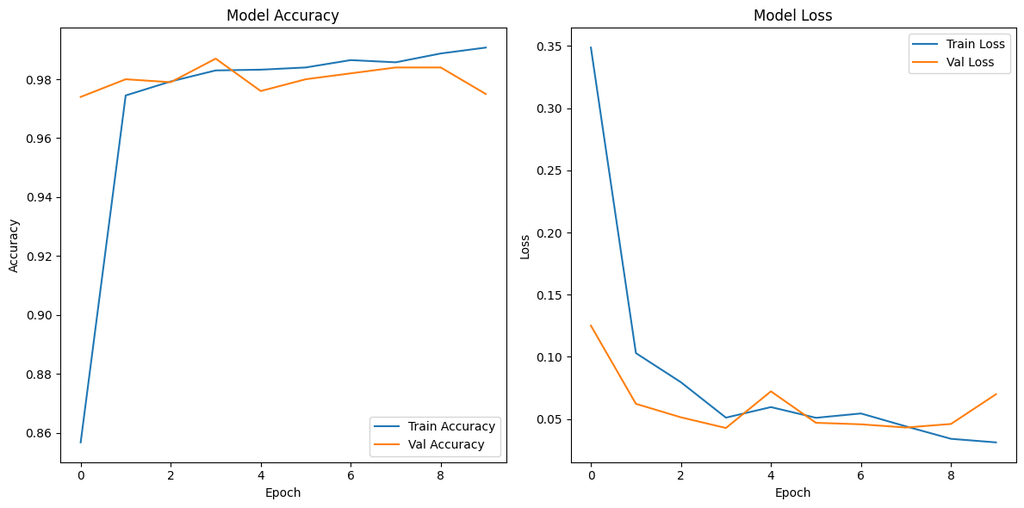

```python
plt.figure(figsize=(12, 6))

plt.subplot(1, 2, 1)
plt.plot(history.history['accuracy'], label='Train Accuracy')
plt.plot(history.history['val_accuracy'], label='Val Accuracy')
plt.title('Model Accuracy')
plt.xlabel('Epoch')
plt.ylabel('Accuracy')
plt.legend()

plt.subplot(1, 2, 2)
plt.plot(history.history['loss'], label='Train Loss')
plt.plot(history.history['val_loss'], label='Val Loss')
plt.title('Model Loss')
plt.xlabel('Epoch')
plt.ylabel('Loss')
plt.legend()

plt.tight_layout()
plt.show()
```

```
              precision    recall  f1-score   support

    No Crack       0.96      0.99      0.98       493
       Crack       0.99      0.96      0.97       507

    accuracy                           0.97      1000
   macro avg       0.98      0.98      0.97      1000
weighted avg       0.98      0.97      0.97      1000
```

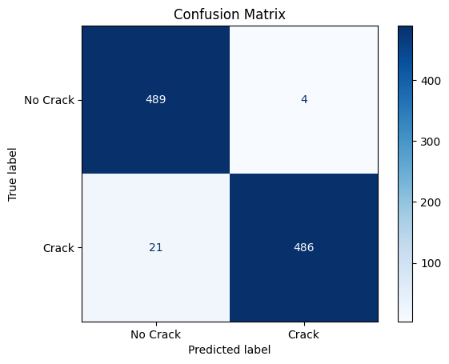

```python
y_pred_probs = model0.predict(X_val)
y_pred = (y_pred_probs > 0.5).astype("int32").flatten()

print(classification_report(y_val, y_pred, target_names=["No Crack", "Crack"]))

cm = confusion_matrix(y_val, y_pred)
disp = ConfusionMatrixDisplay(confusion_matrix=cm, display_labels=["No Crack", "Crack"])
disp.plot(cmap='Blues')
plt.title("Confusion Matrix")
plt.show()
```

### Pre-trained model

```python
base_model = VGG16(weights='imagenet', include_top=False, input_shape=(128, 128, 3))

base_model.trainable = False

model = models.Sequential([
    base_model,
    layers.GlobalAveragePooling2D(),
    layers.Dense(128, activation='relu'),
    layers.Dropout(0.5),
    layers.Dense(1, activation='sigmoid')
])

model.compile(optimizer='adam', loss='binary_crossentropy', metrics=['accuracy'])

model.summary()
```

```
Model: "sequential_2"
_________________________________________________________________
 Layer (type)                Output Shape              Param #
=================================================================
 vgg16 (Functional)          (None, 4, 4, 512)         14714688

 global_average_pooling2d_1  (None, 512)               0
  (GlobalAveragePooling2D)

 dense_4 (Dense)             (None, 128)               65664

 dropout_2 (Dropout)         (None, 128)               0

 dense_5 (Dense)             (None, 1)                 129

=================================================================
Total params: 14780481 (56.38 MB)
Trainable params: 65793 (257.00 KB)
Non-trainable params: 14714688 (56.13 MB)
_________________________________________________________________
```

```python
train_datagen = ImageDataGenerator(
    rescale=1.0/255.0,
    rotation_range=20,
    width_shift_range=0.2,
    height_shift_range=0.2,
    shear_range=0.2,
    zoom_range=0.2,
    horizontal_flip=True,
    fill_mode='nearest'
)

val_datagen = ImageDataGenerator(rescale=1.0/255.0)

train_generator = train_datagen.flow(X_train, y_train, batch_size=32)
val_generator = val_datagen.flow(X_val, y_val, batch_size=32)

history = model.fit(
    train_generator,
    epochs=10,
    validation_data=val_generator,
    shuffle=True
)
```

[output not shown]

```python
# Save both models to avoid re-training
model0.save("cnn_crack_model.h5")
model0.save("cnn_crack_model_tf")
```

```
INFO:tensorflow:Assets written to: cnn_crack_model_tf\assets
```

```
INFO:tensorflow:Assets written to: cnn_crack_model_tf\assets
```

## Test with an example

We want to also test the CNN model with an actual image that is taken from a different angle and is not zoomed in, so we can see hwo the model performs.

```
The image contains a crack.
```

[figure not shown]

```python
def preprocess_image(image_path, target_size=(128, 128)):
    img = load_img(image_path, target_size=target_size)
    img = img_to_array(img)
    img = img / 255.0
    img = np.expand_dims(img, axis=0)
    return img


new_image_path = 'cracksPavements/test.jpg'

processed_image = preprocess_image(new_image_path)

prediction = model0.predict(processed_image)

if prediction[0] > 0.5:
    print("The image contains a crack.")
else:
    print("The image does not contain a crack.")

img = load_img(new_image_path)
plt.imshow(img)
plt.title("New Image for Prediction")
plt.axis('off')
plt.show()
```

## Grad-CAM

It is really important for proper model evaluation to use explainable AI tools like Grad-CAM. This shows us a heatmap of where the model is exactly looking at, so we can make correct conclusions.

```python
def show_gradcam_cnn_with_bbox(img_path, model, last_conv_layer_name="conv2d_2", alpha=0.4, threshold=0.5):
    img_array = get_img_array(img_path)
    heatmap = make_gradcam_heatmap_cnn(img_array, model, last_conv_layer_name)

    heatmap_resized = cv2.resize(heatmap, (128, 128))

    binary_map = np.uint8(heatmap_resized > threshold)

    contours, _ = cv2.findContours(binary_map, cv2.RETR_EXTERNAL, cv2.CHAIN_APPROX_SIMPLE)

    img = cv2.imread(img_path)
    img = cv2.resize(img, (128, 128))

    heatmap_color = cv2.applyColorMap(np.uint8(255 * heatmap_resized), cv2.COLORMAP_JET)
    heatmap_color = cv2.cvtColor(heatmap_color, cv2.COLOR_BGR2RGB)
    superimposed_img = np.uint8(heatmap_color * alpha + img)

    for contour in contours:
        if cv2.contourArea(contour) > 20:
            x, y, w, h = cv2.boundingRect(contour)
            cv2.rectangle(superimposed_img, (x, y), (x + w, y + h), (255, 255, 0), 2)

    plt.figure(figsize=(10, 5))
    plt.subplot(1, 2, 1)
    plt.imshow(cv2.cvtColor(img, cv2.COLOR_BGR2RGB))
    plt.title("Original")
    plt.axis("off")

    plt.subplot(1, 2, 2)
    plt.imshow(superimposed_img)
    plt.title("Grad-CAM + Bounding Box")
    plt.axis("off")
    plt.tight_layout()
    plt.show()
```

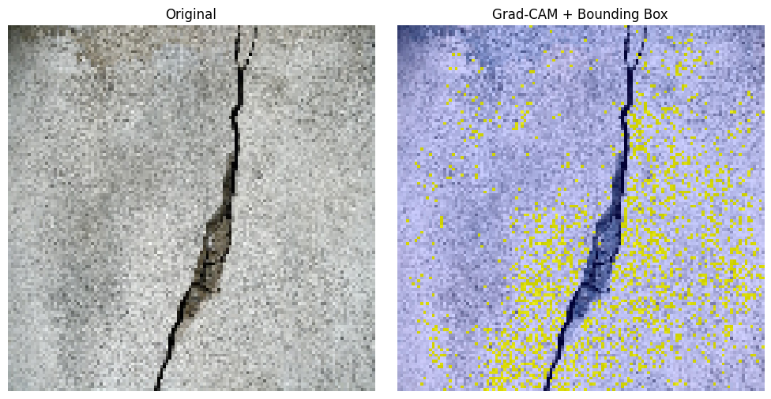

```python
show_gradcam_cnn_with_bbox("cracksPavements/test2.jpg", model0)
```

As we can see, the model is not at all sure and the heatmap is very weak. This means that we need to improve our models. One really important aspect of our project is to be able to find a crack in a drone picture and show where that crack is. Since we are doing a classification. The models predict yes or no on whether there is a crack or not. So, in other words, the model has no idea where that crack is in the picture. We are not using a model like YOLO that is a detection model and draws a bounding box around the crack. The approach for now that we are going to follow is to improve our current models with hyperparameter tuning, more epochs, etc. Then, we are going to use the Grad-CAM heatmap to draw a bounding box around the most "heated area", assuming the model is performing well and looking at the right thing. We are also going to explore Masking and use more data (especially data from far away, so images that contain other things, not just a wall with a crack).

## Iteration 2

We decided to iterate one more time through Data Collection to diversify the data. We downloaded more positive and negative images, will generate synthetic data based on them and will still keep the initial data we had but in a smaller amount to avoid biases. We are going to retrain the models and evaluate the results. Overall, we are expecting less accuracy but better heatmaps.

```python
positive_path = "crackData/positive"
positive_images_2 = os.listdir(positive_path)
negative_path = "crackData/negative"
negative_images_2 = os.listdir(negative_path)
```

## PreProcessing

```python
def preprocess_image_format(input_path, output_path, target_size=(256, 256), target_format="jpeg"):
    os.makedirs(output_path, exist_ok=True)

    for filename in os.listdir(input_path):
        if filename.lower().endswith(('.jpg', '.jpeg', '.png', '.bmp')):
            img_path = os.path.join(input_path, filename)
            img = Image.open(img_path).convert("RGB")
            img = img.resize(target_size)

            new_filename = os.path.splitext(filename)[0] + '.' + target_format
            img.save(os.path.join(output_path, new_filename), format=target_format.upper())

    print(f"Preprocessing complete for: {input_path}")

base_path = "crackData"

positive_input = os.path.join(base_path, "positive")
positive_output = os.path.join(base_path, "positive_cleaned")

negative_input = os.path.join(base_path, "negative")
negative_output = os.path.join(base_path, "negative_cleaned")
preprocess_image_format(positive_input, positive_output)
preprocess_image_format(negative_input, negative_output)
```

```
Preprocessing complete for: crackData\positive
Preprocessing complete for: crackData\negative
```

### Generation of Synthetic Data

We are going to use the ImageDataGenerator to create more training data based on the images we have downloaded, as we have enough of the initial data.

```python
datagen = ImageDataGenerator(
    rescale=1./255,              # Normalize pixel values
    rotation_range=20,           # Random rotation
    width_shift_range=0.2,       # Horizontal shift
    height_shift_range=0.2,      # Vertical shift
    shear_range=0.2,             # Shear intensity
    zoom_range=0.2,              # Zoom in
    horizontal_flip=True,        # Randomly flip
    fill_mode='nearest'          # Fill mode for new pixels
)

batch_size = 32
img_height = 150
img_width = 150

train_generator = datagen.flow_from_directory(
    directory='crackData',     # Root directory
    target_size=(img_height, img_width),  # Resize images
    batch_size=batch_size,
    class_mode='binary',           # Use 'binary' since it's two classes
    shuffle=True
)

images, labels = next(train_generator)

for i in range(9):
    plt.subplot(3, 3, i + 1)
    plt.imshow(images[i])
    plt.title(f'Label: {int(labels[i])}')
    plt.axis('off')

plt.tight_layout()
plt.show()
```

[output not shown]

```python
def augment_and_save(input_dir, output_dir, label, n_augmented=100):
    os.makedirs(output_dir, exist_ok=True)

    datagen = ImageDataGenerator(
        rescale=1./255,
        rotation_range=20,
        width_shift_range=0.2,
        height_shift_range=0.2,
        shear_range=0.2,
        zoom_range=0.2,
        horizontal_flip=True,
        fill_mode='nearest'
    )

    images = [f for f in os.listdir(input_dir) if f.lower().endswith(('.jpg', '.jpeg', '.png'))]
    print(f"Augmenting {len(images)} images from {input_dir}")

    image_count = 0
    for image_name in images:
        image_path = os.path.join(input_dir, image_name)
        img = load_img(image_path, target_size=(150, 150))
        x = img_to_array(img)
        x = x.reshape((1,) + x.shape)  # reshape to (1, height, width, channels)

        prefix = f"{label}_{os.path.splitext(image_name)[0]}"
        i = 0
        for batch in datagen.flow(x, batch_size=1):
            save_path = os.path.join(output_dir, f"{prefix}_aug{i}.jpg")
            save_img(save_path, batch[0])
            i += 1
            image_count += 1
            if i >= n_augmented:
                break

    print(f"Saved {image_count} augmented images to {output_dir}")
```

```python
augment_and_save('crackData/positive_cleaned', 'augmented/positive', label='pos', n_augmented=3)
augment_and_save('crackData/negative_cleaned', 'augmented/negative', label='neg', n_augmented=3)
```

```
Augmenting 62 images from crackData/positive_cleaned
Saved 186 augmented images to augmented/positive
Augmenting 36 images from crackData/negative_cleaned
Saved 108 augmented images to augmented/negative
```

```python
import shutil

def merge_image_folders(sources, destination):
    os.makedirs(destination, exist_ok=True)

    for src in sources:
        for filename in os.listdir(src):
            if filename.lower().endswith(('.jpg', '.jpeg', '.png', '.bmp')):
                src_file = os.path.join(src, filename)
                dst_file = os.path.join(destination, f"{os.path.basename(src)}_{filename}")
                shutil.copy2(src_file, dst_file)

    print(f"Merged into: {destination}")

merge_image_folders(['augmented/positive', 'cracksPavements/Positive'], 'final_dataset/positive')
merge_image_folders(['augmented/negative', 'cracksPavements/Negative'], 'final_dataset/negative')
```

```
Merged into: final_dataset/positive
Merged into: final_dataset/negative
```

```python
positive_path = "final_dataset/positive"
negative_path = "final_dataset/negative"

positive_images = os.listdir(positive_path)
negative_images = os.listdir(negative_path)

image_paths = []
labels = []

for image_name in positive_images:
    image_path = os.path.join(positive_path, image_name)
    image_paths.append(image_path)
    labels.append(1)

for image_name in negative_images:
    image_path = os.path.join(negative_path, image_name)
    image_paths.append(image_path)
    labels.append(0)

img = Image.open(image_paths[0])
img.show()

print("Sample image paths and labels:")
for i in range(5):
    print(f"Image Path: {image_paths[i]} | Label: {labels[i]}")
```

```
Sample image paths and labels:
Image Path: final_dataset/positive\Positive_00001.jpg | Label: 1
Image Path: final_dataset/positive\Positive_00002.jpg | Label: 1
Image Path: final_dataset/positive\Positive_00003.jpg | Label: 1
Image Path: final_dataset/positive\Positive_00004.jpg | Label: 1
Image Path: final_dataset/positive\Positive_00005.jpg | Label: 1
```

```python
all_image_paths = [
    os.path.join(positive_path, img) for img in os.listdir(positive_path)
] + [
    os.path.join(negative_path, img) for img in os.listdir(negative_path)
]

image_properties = {}

for img_path in all_image_paths:
    try:
        with Image.open(img_path) as img:
            img_format = img.format
            img_size = img.size
            img_mode = img.mode

            key = (img_format, img_size, img_mode)
            if key in image_properties:
                image_properties[key] += 1
            else:
                image_properties[key] = 1

    except Exception as e:
        print(f"Error loading image {img_path}: {e}")
for props, count in image_properties.items():
    print(f"Format: {props[0]}, Size: {props[1]}, Mode: {props[2]} - {count} images")
```

```
Format: JPEG, Size: (227, 227), Mode: RGB - 2016 images
Format: JPEG, Size: (150, 150), Mode: RGB - 294 images
```

```python
def preprocess_image(image_path, target_size=(128, 128)):
    img = load_img(image_path, target_size=target_size)
    img = img_to_array(img)
    img = img / 255.0
    return img

processed_images = np.array([preprocess_image(img_path) for img_path in image_paths], dtype=np.float32)
labels = np.array(labels)
```

Now, we are going to combine with the old dataset, but with a reduced size.

```python
X_train_2, X_val_2, y_train_2, y_val_2 = train_test_split(processed_images, labels, test_size=0.2, random_state=42)

print(f"Training data shape: {X_train_2.shape}")
print(f"Validation data shape: {X_val_2.shape}")

train_dataset = tf.data.Dataset.from_tensor_slices((X_train_2, y_train_2))
val_dataset = tf.data.Dataset.from_tensor_slices((X_val_2, y_val_2))

train_dataset = train_dataset.shuffle(buffer_size=1000).batch(32).prefetch(tf.data.experimental.AUTOTUNE)
val_dataset = val_dataset.batch(32).prefetch(tf.data.experimental.AUTOTUNE)
```

```
Training data shape: (1848, 128, 128, 3)
Validation data shape: (462, 128, 128, 3)
```

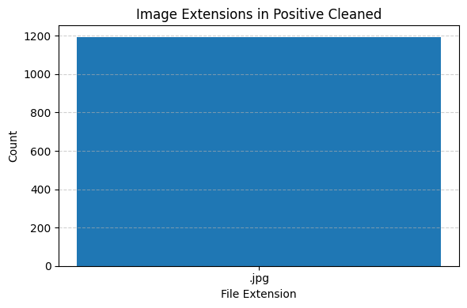

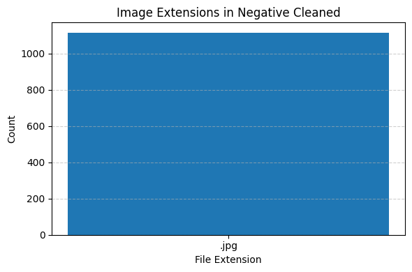

```python
from collections import Counter

def plot_extension_distribution(folder_path, title):
    # Get all file extensions
    extensions = [os.path.splitext(f)[1].lower() for f in os.listdir(folder_path)
                  if os.path.isfile(os.path.join(folder_path, f))]

    # Count each extension
    counter = Counter(extensions)

    # Plot
    plt.figure(figsize=(6, 4))
    plt.bar(counter.keys(), counter.values())
    plt.title(f"Image Extensions in {title}")
    plt.xlabel("File Extension")
    plt.ylabel("Count")
    plt.grid(axis='y', linestyle='--', alpha=0.6)
    plt.tight_layout()
    plt.show()

# Example usage
positive_cleaned = "final_dataset/positive"
negative_cleaned = "final_dataset/negative"

plot_extension_distribution(positive_cleaned, "Positive Cleaned")
plot_extension_distribution(negative_cleaned, "Negative Cleaned")
```

## Training Custom CNN

We are going to train the same model we have built but with the new data. Then, we will evaluate the results and visualize the model's decisions.

```python
def build_cnn_model(input_shape=(128, 128, 3)):
    model0 = models.Sequential()
    model0.add(layers.Conv2D(32, (3, 3), activation='relu', input_shape=input_shape))
    model0.add(layers.MaxPooling2D((2, 2)))
    model0.add(layers.Conv2D(64, (3, 3), activation='relu'))
    model0.add(layers.MaxPooling2D((2, 2)))
    model0.add(layers.Conv2D(128, (3, 3), activation='relu'))
    model0.add(layers.MaxPooling2D((2, 2)))
    model0.add(layers.Flatten())
    model0.add(layers.Dense(128, activation='relu'))
    model0.add(layers.Dropout(0.5))
    model0.add(layers.Dense(1, activation='sigmoid'))

    model0.compile(optimizer='adam', loss='binary_crossentropy', metrics=['accuracy'])
    return model0

model_refined = build_cnn_model(input_shape=(128, 128, 3))

model_refined.summary()
```

```
WARNING:tensorflow:From C:\Users\anika\AppData\Local\Packages\PythonSoftwareFoundation.Python.3.11_qbz5n2kfra8p0\LocalCache\local-packages\Python311\site-packages\keras\src\backend.py:873: The name tf.get_default_graph is deprecated. Please use tf.compat.v1.get_default_graph instead.

WARNING:tensorflow:From C:\Users\anika\AppData\Local\Packages\PythonSoftwareFoundation.Python.3.11_qbz5n2kfra8p0\LocalCache\local-packages\Python311\site-packages\keras\src\layers\pooling\max_pooling2d.py:161: The name tf.nn.max_pool is deprecated. Please use tf.nn.max_pool2d instead.

WARNING:tensorflow:From C:\Users\anika\AppData\Local\Packages\PythonSoftwareFoundation.Python.3.11_qbz5n2kfra8p0\LocalCache\local-packages\Python311\site-packages\keras\src\optimizers\__init__.py:309: The name tf.train.Optimizer is deprecated. Please use tf.compat.v1.train.Optimizer instead.

Model: "sequential"
_________________________________________________________________
 Layer (type)                Output Shape              Param #
=================================================================
 conv2d (Conv2D)             (None, 126, 126, 32)      896

 max_pooling2d (MaxPooling2  (None, 63, 63, 32)        0
 D)

 conv2d_1 (Conv2D)           (None, 61, 61, 64)        18496

 max_pooling2d_1 (MaxPoolin  (None, 30, 30, 64)        0
 g2D)

 conv2d_2 (Conv2D)           (None, 28, 28, 128)       73856

 max_pooling2d_2 (MaxPoolin  (None, 14, 14, 128)       0
 g2D)

 flatten (Flatten)           (None, 25088)             0

 dense (Dense)               (None, 128)               3211392

 dropout (Dropout)           (None, 128)               0

 dense_1 (Dense)             (None, 1)                 129

=================================================================
Total params: 3304769 (12.61 MB)
Trainable params: 3304769 (12.61 MB)
Non-trainable params: 0 (0.00 Byte)
_________________________________________________________________
```

```python
history_refined = model_refined.fit(
    train_dataset,
    epochs=10,
    validation_data=val_dataset,
    shuffle=True
)
```

[output not shown]

```python
val_loss, val_accuracy = model_refined.evaluate(val_dataset)
print(f"Validation Loss: {val_loss:.4f}")
print(f"Validation Accuracy: {val_accuracy * 100:.2f}%")
```

```
Validation Loss: 0.1449
Validation Accuracy: 94.81%
```

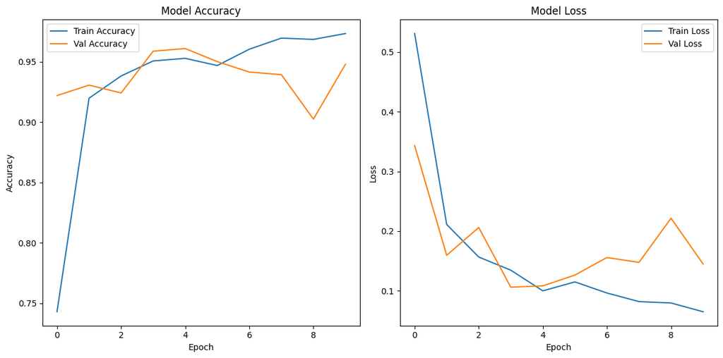

```python
plt.figure(figsize=(12, 6))

plt.subplot(1, 2, 1)
plt.plot(history_refined.history['accuracy'], label='Train Accuracy')
plt.plot(history_refined.history['val_accuracy'], label='Val Accuracy')
plt.title('Model Accuracy')
plt.xlabel('Epoch')
plt.ylabel('Accuracy')
plt.legend()

plt.subplot(1, 2, 2)
plt.plot(history_refined.history['loss'], label='Train Loss')
plt.plot(history_refined.history['val_loss'], label='Val Loss')
plt.title('Model Loss')
plt.xlabel('Epoch')
plt.ylabel('Loss')
plt.legend()

plt.tight_layout()
plt.show()
```

```
              precision    recall  f1-score   support

    No Crack       0.99      0.90      0.95       231
       Crack       0.91      0.99      0.95       231

    accuracy                           0.95       462
   macro avg       0.95      0.95      0.95       462
weighted avg       0.95      0.95      0.95       462
```

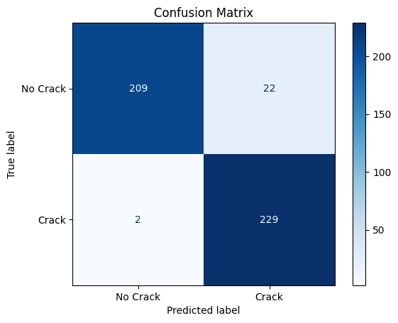

```python
y_pred_probs = model_refined.predict(X_val_2)
y_pred_2 = (y_pred_probs > 0.5).astype("int32").flatten()

print(classification_report(y_val_2, y_pred_2, target_names=["No Crack", "Crack"]))

cm = confusion_matrix(y_val_2, y_pred_2)
disp = ConfusionMatrixDisplay(confusion_matrix=cm, display_labels=["No Crack", "Crack"])
disp.plot(cmap='Blues')
plt.title("Confusion Matrix")
plt.show()
```

```python
def make_gradcam_heatmap(img_array, model, last_conv_layer_name, pred_index=None):
    grad_model = tf.keras.models.Model(
        [model.inputs],
        [model.get_layer(last_conv_layer_name).output, model.output]
    )

    with tf.GradientTape() as tape:
        conv_outputs, predictions = grad_model(img_array)
        if pred_index is None:
            pred_index = tf.argmax(predictions[0])
        class_channel = predictions[:, pred_index]

    grads = tape.gradient(class_channel, conv_outputs)
    pooled_grads = tf.reduce_mean(grads, axis=(0, 1, 2))

    conv_outputs = conv_outputs[0]
    heatmap = conv_outputs @ pooled_grads[..., tf.newaxis]
    heatmap = tf.squeeze(heatmap)

    heatmap = tf.maximum(heatmap, 0) / tf.math.reduce_max(heatmap)
    return heatmap.numpy()

def display_gradcam(image_array, heatmap, alpha=0.4):
    heatmap = cv2.resize(heatmap, (image_array.shape[1], image_array.shape[0]))
    heatmap = np.uint8(255 * heatmap)
    heatmap = cv2.applyColorMap(heatmap, cv2.COLORMAP_JET)
    superimposed_img = heatmap * alpha + np.uint8(image_array * 255)
    return superimposed_img / 255
```

```python
import random

def run_gradcam_on_random_val_images(model, val_dataset, last_conv_layer_name, num_images=4):
    # Load one full batch (or you could iterate across all and gather)
    for batch_images, batch_labels in val_dataset.take(1):
        batch_images = batch_images.numpy()
        batch_labels = batch_labels.numpy()
        break

    indices = random.sample(range(len(batch_images)), num_images)

    plt.figure(figsize=(12, 8))

    for idx, i in enumerate(indices):
        img = batch_images[i]
        label = int(batch_labels[i])
        input_img = np.expand_dims(img, axis=0)

        prediction = model.predict(input_img)[0][0]
        predicted_label = int(prediction > 0.5)

        heatmap = make_gradcam_heatmap(input_img, model, last_conv_layer_name)
        cam = display_gradcam(img, heatmap)

        plt.subplot(2, 2, idx + 1)
        plt.imshow(cam)
        plt.title(f'Pred: {predicted_label} ({prediction:.2f}), True: {label}')
        plt.axis('off')

    plt.tight_layout()
    plt.show()
```

```python
for layer in model_refined.layers[::-1]:
    if isinstance(layer, tf.keras.layers.Conv2D):
        print("Last conv layer:", layer.name)
        break
```

```
Last conv layer: conv2d_2
```

```
Clipping input data to the valid range for imshow with RGB data ([0..1] for floats or [0..255] for integers). Got range [0.21568627450980393..1.4].
```

```
Clipping input data to the valid range for imshow with RGB data ([0..1] for floats or [0..255] for integers). Got range [0.4117647058823529..1.0596078431372549].
```

```
Clipping input data to the valid range for imshow with RGB data ([0..1] for floats or [0..255] for integers). Got range [0.0..1.380392156862745].
```

```
Clipping input data to the valid range for imshow with RGB data ([0..1] for floats or [0..255] for integers). Got range [0.011764705882352941..1.1725490196078432].
```

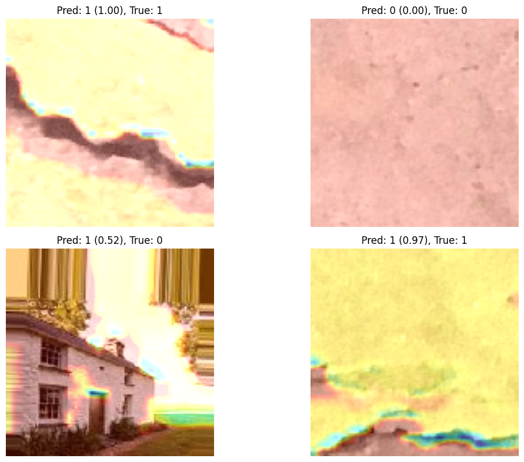

```python
run_gradcam_on_random_val_images(model_refined, val_dataset, last_conv_layer_name='conv2d_2')
```

## Hyperparameter tuning

In this phase, we refined our binary classification model to detect cracks by systematically tuning hyperparameters. We tested several configurations using a CNN-based model and VGG16 as a backbone to identify the best performing setup.

```python
train_datagen = ImageDataGenerator(
    rescale=1./255,
    rotation_range=20,
    width_shift_range=0.2,
    height_shift_range=0.2,
    shear_range=0.2,
    zoom_range=0.2,
    horizontal_flip=True
)

val_datagen = ImageDataGenerator(rescale=1./255)

train_generator = train_datagen.flow(X_train, y_train, batch_size=32)
val_generator = val_datagen.flow(X_val, y_val, batch_size=32)
```

```python
def build_model(dropout_rate=0.5, dense_units=128, optimizer='adam', learning_rate=1e-4):
    base_model = VGG16(weights='imagenet', include_top=False, input_shape=(128, 128, 3))
    base_model.trainable = False

    model = models.Sequential([
        base_model,
        layers.GlobalAveragePooling2D(),
        layers.Dense(dense_units, activation='relu'),
        layers.Dropout(dropout_rate),
        layers.Dense(1, activation='sigmoid')
    ])

    if optimizer == 'adam':
        opt = Adam(learning_rate=learning_rate)
    elif optimizer == 'rmsprop':
        opt = RMSprop(learning_rate=learning_rate)
    else:
        opt = SGD(learning_rate=learning_rate)

    model.compile(optimizer=opt, loss='binary_crossentropy', metrics=['accuracy'])
    return model
```

We implemented a grid search over the chosen hyperparameters using manual loops. For each configuration, we trained the model for up to 20 epochs with data augmentation enabled, and early stopping was manually monitored through validation accuracy trends.

Each training session used the same preprocessed dataset, and performance was evaluated based on validation accuracy and loss curves. The most promising model was retained for detailed evaluation and visualization.

```python
params = {
    'dropout_rate': [0.3, 0.5],
    'dense_units': [64, 128],
    'learning_rate': [1e-4, 1e-5],
    'optimizer': ['adam', 'rmsprop']
}

best_val_acc = 0
best_model = None
best_history = None
best_params = {}

for dr in params['dropout_rate']:
    for du in params['dense_units']:
        for lr in params['learning_rate']:
            for opt in params['optimizer']:
                print(f"Testing config: Dropout={dr}, Dense Units={du}, LR={lr}, Optimizer={opt}")
                model = build_model(dropout_rate=dr, dense_units=du, learning_rate=lr, optimizer=opt)
                history = model.fit(
                    train_generator,
                    validation_data=val_generator,
                    epochs=20,
                    shuffle=True,
                    verbose=0
                )
                val_acc = history.history['val_accuracy'][-1]
                if val_acc > best_val_acc:
                    best_val_acc = val_acc
                    best_model = model
                    best_history = history
                    best_params = {'dropout': dr, 'dense_units': du, 'lr': lr, 'opt': opt}
```

```python
plt.plot(best_history.history['accuracy'], label='Train Accuracy')
plt.plot(best_history.history['val_accuracy'], label='Val Accuracy')
plt.plot(best_history.history['loss'], label='Train Loss')
plt.plot(best_history.history['val_loss'], label='Val Loss')
plt.title('Training and Validation Performance')
plt.xlabel('Epochs')
plt.ylabel('Metrics')
plt.legend()
plt.grid(True)
plt.show()
```

[output not shown]

```python
y_pred = (best_model.predict(val_generator) > 0.5).astype("int32")
y_true = y_val[:len(y_pred)]

print(classification_report(y_true, y_pred))
ConfusionMatrixDisplay(confusion_matrix(y_true, y_pred)).plot()
```

[output not shown]

However, a core limitation remains: the lack of spatial localization. The classification model does not identify where the crack is, which is crucial for real-world drone inspection tasks.

This limitation naturally leads us to the next phase of our project — image segmentation. In upcoming iterations, we will explore segmentation models like U-Net and Mask R-CNN, which are designed to perform pixel-wise classification and can produce highly detailed masks showing the exact location of cracks.

## Tile-based Analysis Strategy

This will be used on the drone imahes to divide the imahes into overlapping tiles and the models will loop through the patches.

```python
from typing import List, Tuple

# extract patches
def get_image_patches(img: np.ndarray, patch_size: int = 256, stride: int = 128) -> List[Tuple[Tuple[int, int], np.ndarray]]:
    patches = []
    h, w, _ = img.shape
    for y in range(0, h - patch_size + 1, stride):
        for x in range(0, w - patch_size + 1, stride):
            patch = img[y:y+patch_size, x:x+patch_size]
            patches.append(((x, y), patch))
    return patches

# testing with dummy model to create masks
def dummy_model_predict(patch: np.ndarray) -> np.ndarray:
    output = np.zeros((patch.shape[0], patch.shape[1]), dtype=np.uint8)
    cv2.line(output, (patch.shape[1]//2, 0), (patch.shape[1]//2, patch.shape[0]), 255, 2)
    return output

# reconstruct a full mask on the real image based on the patches
def reconstruct_full_mask(image_shape: Tuple[int, int], patches: List[Tuple[Tuple[int, int], np.ndarray]], patch_size: int = 256, stride: int = 128) -> np.ndarray:
    h, w = image_shape
    mask = np.zeros((h, w), dtype=np.float32)
    count = np.zeros((h, w), dtype=np.float32)

    for (x, y), patch_mask in patches:
        mask[y:y+patch_size, x:x+patch_size] += patch_mask
        count[y:y+patch_size, x:x+patch_size] += 1

    count[count == 0] = 1
    mask = (mask / count).astype(np.uint8)
    return mask

sample_image = cv2.imread("test.JPG")

patches = get_image_patches(sample_image)

predicted_patches = [((x, y), dummy_model_predict(patch)) for (x, y), patch in patches]

reconstructed_mask = reconstruct_full_mask(sample_image.shape[:2], predicted_patches)
```

```python
image_path = "test.JPG"
image = cv2.imread(image_path)
image_rgb = cv2.cvtColor(image, cv2.COLOR_BGR2RGB)

patch_size = 256
stride = 128
patches = get_image_patches(image, patch_size, stride)

plt.figure(figsize=(6, 6))
plt.imshow(image_rgb)
plt.title("Original Drone Image")
plt.axis("off")
plt.show()

num_patches = len(patches)
cols = 4
rows = (num_patches + cols - 1) // cols

plt.figure(figsize=(15, 3 * rows))
for i, ((x, y), patch) in enumerate(patches):
    plt.subplot(rows, cols, i + 1)
    plt.imshow(cv2.cvtColor(patch, cv2.COLOR_BGR2RGB))
    plt.title(f"Patch {i+1} ({x},{y})")
    plt.axis("off")

plt.tight_layout()
plt.show()
```

[output not shown]

```python
image_path = "test4.JPG"
image = cv2.imread(image_path)
image_rgb = cv2.cvtColor(image, cv2.COLOR_BGR2RGB)

patch_size = 256
stride = 128
patches = get_image_patches(image, patch_size, stride)

plt.figure(figsize=(6, 6))
plt.imshow(image_rgb)
plt.title("Original Internet Image")
plt.axis("off")
plt.show()

num_patches = len(patches)
cols = 4
rows = (num_patches + cols - 1) // cols

plt.figure(figsize=(15, 3 * rows))
for i, ((x, y), patch) in enumerate(patches):
    plt.subplot(rows, cols, i + 1)
    plt.imshow(cv2.cvtColor(patch, cv2.COLOR_BGR2RGB))
    plt.title(f"Patch {i+1} ({x},{y})")
    plt.axis("off")

plt.tight_layout()
plt.show()
```

[output not shown]

```python
image_path_2 = "test4.jpg"
image_2 = cv2.imread(image_path_2)
image_rgb = cv2.cvtColor(image_2, cv2.COLOR_BGR2RGB)

patch_size = 256
stride = 128
patches_2 = get_image_patches(image_2, patch_size, stride)
```

```
Total patches: 660
Cracks detected in 77 patches.
```

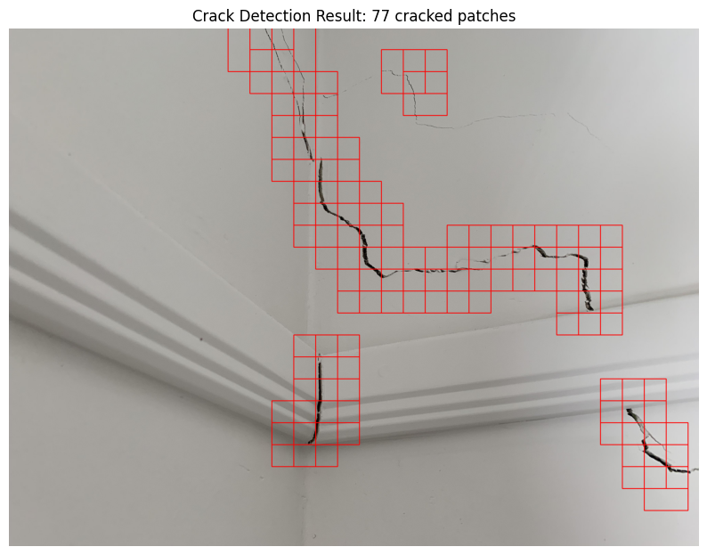

```python
def preprocess_patch(patch):
    patch_resized = cv2.resize(patch, (128, 128))
    patch_normalized = patch_resized / 255.0
    return np.expand_dims(patch_normalized, axis=0)

crack_patches_2 = []
for idx, ((x, y), patch) in enumerate(patches_2):
    input_patch = preprocess_patch(patch)
    prediction = model.predict(input_patch)[0][0]
    if prediction > 0.5:
        crack_patches_2.append((x, y))

print(f"Total patches: {len(patches_2)}")
print(f"Cracks detected in {len(crack_patches_2)} patches.")

image_with_boxes_2 = image_rgb.copy()
for (x, y) in crack_patches_2:
    cv2.rectangle(image_with_boxes_2, (x, y), (x + patch_size, y + patch_size), (255, 0, 0), 3)

plt.figure(figsize=(10, 10))
plt.imshow(image_with_boxes_2)
plt.title(f"Crack Detection Result: {len(crack_patches_2)} cracked patches")
plt.axis("off")
plt.show()
```

## Final Iteration of the Classification models

### Dataset Diversification

In this step, we focus on expanding and diversifying our dataset to improve model generalization and robustness. We first ensure that the output directory is clean by deleting any existing augmented_dataset folder, and we recreate its structure. Next, we define a rich augmentation pipeline using the Albumentations library. This pipeline applies a mix of transformations with certain probabilities, including:

- Random brightness and contrast adjustment (to simulate lighting variability)
- Horizontal and vertical flips (to introduce spatial variety)
- Small rotations (up to 15°) and random scaling (to simulate viewpoint variations)
- Gaussian noise and blur (to mimic sensor imperfections or challenging conditions)

For each original image, we generate 5 augmented versions using random combinations of these transformations. The original image is also copied unchanged to the output directory. This process is crucial because deep learning models often require large and diverse datasets to avoid overfitting. By augmenting the data in this way, we help the model learn more generalizable features that can handle real-world variations.

Important to note is that after the creation of the augmented dataset, it is manually checked if the images are looking okay and to verify they can be used further. This way, wavelet was removed as a step in the pipeline.

```python
import os
import cv2
import albumentations as A
import numpy as np
from tqdm import tqdm
import shutil

INPUT_DIR = 'final_dataset'
OUTPUT_DIR = 'augmented_dataset'
CLASSES = ['positive', 'negative']

if os.path.exists(OUTPUT_DIR):
    shutil.rmtree(OUTPUT_DIR)
for cls in CLASSES:
    os.makedirs(os.path.join(OUTPUT_DIR, cls), exist_ok=True)

augmentations = A.Compose([
    A.RandomBrightnessContrast(p=0.3),
    A.HorizontalFlip(p=0.5),
    A.VerticalFlip(p=0.3),
    A.Rotate(limit=15, p=0.4),
    A.RandomScale(scale_limit=0.1, p=0.3),
    A.GaussNoise(var_limit=(5.0, 20.0), p=0.1),
    A.Blur(blur_limit=3, p=0.1)
])

AUG_PER_IMAGE = 5

for cls in CLASSES:
    input_folder = os.path.join(INPUT_DIR, cls)
    output_folder = os.path.join(OUTPUT_DIR, cls)
    images = os.listdir(input_folder)

    for img_name in tqdm(images, desc=f"Augmenting {cls}"):
        img_path = os.path.join(input_folder, img_name)
        image = cv2.imread(img_path)

        if image is None:
            print(f"Warning: Couldn't read {img_path}, skipping.")
            continue

        cv2.imwrite(os.path.join(output_folder, img_name), image)

        for i in range(AUG_PER_IMAGE):
            augmented = augmentations(image=image)['image']
            save_name = f"{os.path.splitext(img_name)[0]}_aug{i}.jpg"
            cv2.imwrite(os.path.join(output_folder, save_name), augmented)
```

### Setup and Data Loaders

In this part of the final iteration, we set up the data pipeline that will be used for training, validating, and testing our models. The code loads our augmented dataset and applies standard preprocessing, including resizing the images to 224×224 pixels and normalizing their pixel values to improve model training stability. We then split the dataset into training, validation, and test sets, ensuring that we have separate data for learning, tuning, and final evaluation. This split helps us avoid overfitting and provides an unbiased way to measure the model’s performance on unseen data. DataLoaders are created to handle batching and shuffling during training, allowing for efficient and reliable feeding of data to the models in upcoming steps.

```python
import os
import torch
from torch.utils.data import DataLoader, random_split
from torchvision import datasets, transforms
from torchvision.datasets import ImageFolder
from torchvision.transforms import ToTensor
import torchvision.models as models
import torch.nn as nn
import torch.optim as optim
from tqdm import tqdm

BATCH_SIZE = 32
IMG_SIZE = 224
DATA_DIR = "augmented_dataset"
NUM_CLASSES = 2
EPOCHS = 20
DEVICE = torch.device("cuda" if torch.cuda.is_available() else "cpu")

basic_transforms = transforms.Compose([
    transforms.Resize((IMG_SIZE, IMG_SIZE)),
    transforms.ToTensor(),
    transforms.Normalize([0.5]*3, [0.5]*3)
])

dataset = ImageFolder(DATA_DIR, transform=basic_transforms)
train_size = int(0.7 * len(dataset))
val_size = int(0.2 * len(dataset))
test_size = len(dataset) - train_size - val_size
train_ds, val_ds, test_ds = random_split(dataset, [train_size, val_size, test_size])

train_loader = DataLoader(train_ds, batch_size=BATCH_SIZE, shuffle=True)
val_loader = DataLoader(val_ds, batch_size=BATCH_SIZE)
test_loader = DataLoader(test_ds, batch_size=BATCH_SIZE)
```

### Modeling

Now, we are going to train new custom CNN, pre-trained model, lightweight attention model and more advanced attention model on the new dataset.

#### Custom CNN

Now, we define and train a custom convolutional neural network (CNN) designed for crack detection. The architecture consists of several convolutional layers followed by ReLU activations and max-pooling operations, which progressively extract spatial features from the input images while reducing their dimensions. After the convolutional layers, the data is flattened and passed through two fully connected layers, with dropout applied to help prevent overfitting. The final layer outputs predictions for our two classes: crack or no crack. The model is trained over multiple epochs, where in each epoch it processes batches of training data, computes the loss, and updates its parameters. After each epoch, we print the average loss to monitor how well the model is learning.

```python
class CustomCNN(nn.Module):
    def __init__(self):
        super().__init__()
        self.model = nn.Sequential(
            nn.Conv2d(3, 32, 3, padding=1), nn.ReLU(), nn.MaxPool2d(2),
            nn.Conv2d(32, 64, 3, padding=1), nn.ReLU(), nn.MaxPool2d(2),
            nn.Conv2d(64, 128, 3, padding=1), nn.ReLU(), nn.MaxPool2d(2),
            nn.Flatten(),
            nn.Linear(128 * (IMG_SIZE // 8) * (IMG_SIZE // 8), 128), nn.ReLU(),
            nn.Dropout(0.3),
            nn.Linear(128, NUM_CLASSES)
        )

    def forward(self, x):
        return self.model(x)

def train_model(model, name):
    model = model.to(DEVICE)
    criterion = nn.CrossEntropyLoss()
    optimizer = optim.Adam(model.parameters(), lr=0.001)

    for epoch in range(EPOCHS):
        model.train()
        running_loss = 0
        for images, labels in tqdm(train_loader, desc=f"{name} - Epoch {epoch+1}"):
            images, labels = images.to(DEVICE), labels.to(DEVICE)
            outputs = model(images)
            loss = criterion(outputs, labels)

            optimizer.zero_grad()
            loss.backward()
            optimizer.step()
            running_loss += loss.item()

        print(f"[{name}] Epoch {epoch+1}, Loss: {running_loss/len(train_loader):.4f}")

    torch.save(model.state_dict(), f"{name}_model.pth")

custom_model = CustomCNN()
train_model(custom_model, "custom_cnn")
```

#### Transfer Learning (ResNet18)

In this step, we train a transfer learning model based on ResNet-18, a well-known convolutional neural network architecture that has been pretrained on ImageNet, a large and diverse image dataset. By using a pretrained model, we take advantage of the fact that it has already learned general visual features like edges, textures, and shapes, which are useful for many computer vision tasks, including crack detection. We freeze all of ResNet-18’s existing layers so that these learned features remain unchanged during training, focusing our efforts on learning only the final classification layers. We replace the original fully connected layer with a new head that first reduces the output size to 128 units, applies ReLU activation and dropout for regularization, and finally outputs predictions for our two classes. We then train this modified model using the same training function as before. This approach allows us to benefit from the power of a large, pretrained model while keeping training efficient and reducing the risk of overfitting on our smaller dataset.

```python
resnet = models.resnet18(pretrained=True)
for param in resnet.parameters():
    param.requires_grad = False

resnet.fc = nn.Sequential(
    nn.Linear(resnet.fc.in_features, 128),
    nn.ReLU(),
    nn.Dropout(0.3),
    nn.Linear(128, NUM_CLASSES)
)

train_model(resnet, "resnet18_transfer")
```

In this part of the final iteration, we design and train a custom convolutional neural network that incorporates lightweight attention mechanisms using Squeeze-and-Excitation (SE) blocks. The SE block is a form of channel-wise attention that helps the model emphasize important features while suppressing less useful ones. It does this by learning to scale each channel of the convolutional output based on global context. This enhances the model’s ability to focus on patterns that are more relevant to crack detection. The CNNWithSE architecture consists of three convolutional layers, each followed by an SE block that recalibrates the feature maps. After each SE block, max pooling reduces the spatial dimensions, helping the model capture increasingly abstract representations. The output is flattened and passed through fully connected layers with dropout for regularization, ultimately predicting one of the two classes. We train this model using our previously defined training function, which handles loss computation, optimization, and saving the trained model. By incorporating SE blocks, we aim to improve the model’s accuracy without significantly increasing its complexity, making it more effective at distinguishing subtle features of cracks.

```python
class SEBlock(nn.Module):
    def __init__(self, in_channels, reduction=16):
        super().__init__()
        self.pool = nn.AdaptiveAvgPool2d(1)
        self.fc = nn.Sequential(
            nn.Linear(in_channels, in_channels // reduction), nn.ReLU(),
            nn.Linear(in_channels // reduction, in_channels), nn.Sigmoid()
        )

    def forward(self, x):
        b, c, _, _ = x.size()
        y = self.pool(x).view(b, c)
        y = self.fc(y).view(b, c, 1, 1)
        return x * y.expand_as(x)

class CNNWithSE(nn.Module):
    def __init__(self):
        super().__init__()
        self.conv1 = nn.Conv2d(3, 32, 3, padding=1)
        self.se1 = SEBlock(32)
        self.conv2 = nn.Conv2d(32, 64, 3, padding=1)
        self.se2 = SEBlock(64)
        self.conv3 = nn.Conv2d(64, 128, 3, padding=1)
        self.se3 = SEBlock(128)
        self.pool = nn.MaxPool2d(2)
        self.fc = nn.Sequential(
            nn.Flatten(),
            nn.Linear(128 * (IMG_SIZE // 8) * (IMG_SIZE // 8), 128), nn.ReLU(),
            nn.Dropout(0.3),
            nn.Linear(128, NUM_CLASSES)
        )

    def forward(self, x):
        x = self.pool(self.se1(self.conv1(x)))
        x = self.pool(self.se2(self.conv2(x)))
        x = self.pool(self.se3(self.conv3(x)))
        return self.fc(x)

se_model = CNNWithSE()
train_model(se_model, "cnn_with_se")
```

#### Vision Transformer (ViT) Classifier

In this step, we prepare a dedicated data pipeline for training a Vision Transformer (ViT) model. Since Vision Transformers often benefit from slightly different preprocessing than traditional CNNs, we define a transformation pipeline that resizes the images to 224×224 pixels, converts them to tensors, and normalizes them using the mean and standard deviation values from the ImageNet dataset, on which most ViT models are pretrained. This ensures that our input data is compatible with the expectations of the pretrained ViT model.

We load the dataset from the augmented images directory and split it into training, validation, and test sets, using the same proportions as before (70% training, 20% validation, and 10% testing). Finally, we create DataLoaders for each subset to enable efficient, batched processing of the data during training and evaluation.

```python
import os
import torch
from torch.utils.data import DataLoader, random_split
from torchvision.datasets import ImageFolder
from torchvision import transforms
from tqdm import tqdm

DEVICE = torch.device("cuda" if torch.cuda.is_available() else "cpu")

DATA_DIR = "augmented_dataset"
IMG_SIZE = 224
NUM_CLASSES = 2
BATCH_SIZE = 32
EPOCHS = 20

vit_transforms = transforms.Compose([
    transforms.Resize((IMG_SIZE, IMG_SIZE)),
    transforms.ToTensor(),
    transforms.Normalize(mean=[0.485, 0.456, 0.406],
                         std=[0.229, 0.224, 0.225])
])

vit_dataset = ImageFolder(DATA_DIR, transform=vit_transforms)
train_size = int(0.7 * len(vit_dataset))
val_size = int(0.2 * len(vit_dataset))
test_size = len(vit_dataset) - train_size - val_size
vit_train, vit_val, vit_test = random_split(vit_dataset, [train_size, val_size, test_size])

vit_train_loader = DataLoader(vit_train, batch_size=BATCH_SIZE, shuffle=True)
vit_val_loader = DataLoader(vit_val, batch_size=BATCH_SIZE)
vit_test_loader = DataLoader(vit_test, batch_size=BATCH_SIZE)
```

In this part of the final iteration, we set up and train a Vision Transformer (ViT) model using transfer learning. We start by creating a ViT architecture (vit_base_patch16_224) from the timm library and load pretrained weights from ImageNet. This allows us to leverage the rich visual representations the model has already learned from a large, diverse dataset. We replace the default classification head with a new custom head designed for our binary classification task. The new head first reduces the features to 128 units, applies ReLU activation and dropout for regularization, and finally outputs predictions for our two classes.

We define a training function specifically for the ViT, where the model is trained using cross-entropy loss and the Adam optimizer. The learning rate is set lower (1e-4) compared to typical CNNs, as fine-tuning large pretrained models often requires smaller steps to avoid destabilizing their learned representations. The model is trained over multiple epochs, with the average loss printed at the end of each epoch to help monitor learning progress. Once training is complete, we save the model’s parameters so they can be used later for evaluation or deployment. This step enables us to explore how attention-based architectures perform on the crack detection task compared to CNNs.

```python
import timm
import torch.nn as nn
import torch.optim as optim

vit_model = timm.create_model('vit_base_patch16_224', pretrained=True)

vit_model.head = nn.Sequential(
    nn.Linear(vit_model.head.in_features, 128),
    nn.ReLU(),
    nn.Dropout(0.3),
    nn.Linear(128, NUM_CLASSES)
)

def train_model_vit(model, name, train_loader, val_loader):
    model = model.to(DEVICE)
    criterion = nn.CrossEntropyLoss()
    optimizer = optim.Adam(model.parameters(), lr=1e-4)

    for epoch in range(EPOCHS):
        model.train()
        total_loss = 0

        for images, labels in tqdm(train_loader, desc=f"{name} - Epoch {epoch+1}"):
            images, labels = images.to(DEVICE), labels.to(DEVICE)

            outputs = model(images)
            loss = criterion(outputs, labels)

            optimizer.zero_grad()
            loss.backward()
            optimizer.step()

            total_loss += loss.item()

        print(f"[{name}] Epoch {epoch+1}, Loss: {total_loss / len(train_loader):.4f}")

    torch.save(model.state_dict(), f"{name}_model.pth")

train_model_vit(vit_model, "vit_base_patch16", vit_train_loader, vit_val_loader)
```

### Evaluation

```python
from sklearn.metrics import classification_report, confusion_matrix
import numpy as np

def evaluate_model(model, dataloader, model_name):
    model.eval()
    model.to(DEVICE)
    all_preds = []
    all_labels = []

    with torch.no_grad():
        for images, labels in dataloader:
            images = images.to(DEVICE)
            outputs = model(images)
            preds = torch.argmax(outputs, dim=1).cpu().numpy()
            all_preds.extend(preds)
            all_labels.extend(labels.numpy())

    print(f"📊 Evaluation for {model_name}")
    print(confusion_matrix(all_labels, all_preds))
    print(classification_report(all_labels, all_preds, target_names=['Negative', 'Positive']))
```

An important thing for this project is that we need a lot more evaluation techniques than just the common metrics and we will do that further.

```python
custom_model = CustomCNN()
custom_model.load_state_dict(torch.load("custom_cnn_model.pth"))
evaluate_model(custom_model, test_loader, "Custom CNN")
```

```
📊 Evaluation for Custom CNN
[[202  15]
 [ 22 193]]
              precision    recall  f1-score   support

    Negative       0.90      0.93      0.92       217
    Positive       0.93      0.90      0.91       215

    accuracy                           0.91       432
   macro avg       0.91      0.91      0.91       432
weighted avg       0.91      0.91      0.91       432
```

```python
resnet = models.resnet18()
resnet.fc = nn.Sequential(
    nn.Linear(resnet.fc.in_features, 128),
    nn.ReLU(),
    nn.Dropout(0.3),
    nn.Linear(128, NUM_CLASSES)
)
resnet.load_state_dict(torch.load("resnet18_transfer_model.pth"))
evaluate_model(resnet, test_loader, "ResNet18")
```

```
📊 Evaluation for ResNet18
[[210   7]
 [  8 207]]
              precision    recall  f1-score   support

    Negative       0.96      0.97      0.97       217
    Positive       0.97      0.96      0.97       215

    accuracy                           0.97       432
   macro avg       0.97      0.97      0.97       432
weighted avg       0.97      0.97      0.97       432
```

```python
se_model = CNNWithSE()
se_model.load_state_dict(torch.load("cnn_with_se_model.pth"))
evaluate_model(se_model, test_loader, "CNN with SE")
```

```
📊 Evaluation for CNN with SE
[[209   8]
 [ 59 156]]
              precision    recall  f1-score   support

    Negative       0.78      0.96      0.86       217
    Positive       0.95      0.73      0.82       215

    accuracy                           0.84       432
   macro avg       0.87      0.84      0.84       432
weighted avg       0.87      0.84      0.84       432
```

```python
vit_model = timm.create_model('vit_base_patch16_224', pretrained=False, num_classes=NUM_CLASSES)
vit_model.head = nn.Sequential(
    nn.Linear(vit_model.head.in_features, 128),
    nn.ReLU(),
    nn.Dropout(0.3),
    nn.Linear(128, NUM_CLASSES)
)
vit_model.load_state_dict(torch.load("vit_base_patch16_model.pth"))
evaluate_model(vit_model, vit_test_loader, "ViT")
```

```
📊 Evaluation for ViT
[[202   5]
 [  5 220]]
              precision    recall  f1-score   support

    Negative       0.98      0.98      0.98       207
    Positive       0.98      0.98      0.98       225

    accuracy                           0.98       432
   macro avg       0.98      0.98      0.98       432
weighted avg       0.98      0.98      0.98       432
```

### Grad-CAM

Now, we are going to dive into explainable AI and see where our models are looking at when making predictions. This can help us in the evaluation. For the ViT model, no explainable AI was available.

```python
from pytorch_grad_cam import GradCAM
from pytorch_grad_cam.utils.model_targets import ClassifierOutputTarget
from pytorch_grad_cam.utils.image import show_cam_on_image
import matplotlib.pyplot as plt
import numpy as np
import cv2

def run_gradcam(model, dataloader, target_layer, model_name):
    model.eval().to(DEVICE)

    correct = []
    incorrect = []

    with GradCAM(model=model, target_layers=[target_layer]) as cam:
        for images, labels in dataloader:
            images, labels = images.to(DEVICE), labels.to(DEVICE)

            outputs = model(images)
            preds = torch.argmax(outputs, dim=1)

            for i in range(len(images)):
                pred = preds[i].item()
                true = labels[i].item()

                image_tensor = images[i].unsqueeze(0).clone().detach()
                image_tensor.requires_grad = True

                image_np = image_tensor.squeeze().detach().permute(1, 2, 0).cpu().numpy()
                image_np = (image_np * 0.5 + 0.5).clip(0, 1)

                grayscale_cam = cam(input_tensor=image_tensor, targets=[ClassifierOutputTarget(pred)])
                visualization = show_cam_on_image(image_np, grayscale_cam[0], use_rgb=True)

                entry = (image_np, visualization, pred, true)
                if pred == true and len(correct) < 5:
                    correct.append(entry)
                elif pred != true and len(incorrect) < 5:
                    incorrect.append(entry)

                if len(correct) >= 5 and len(incorrect) >= 5:
                    break
            if len(correct) >= 5 and len(incorrect) >= 5:
                break

    def show_samples(title, samples):
        print(f"🔍 {title}")
        plt.figure(figsize=(15, 6))
        for i, (orig, cam, pred, true) in enumerate(samples):
            plt.subplot(2, 5, i + 1)
            plt.imshow(cam)
            plt.title(f"Pred: {pred}, True: {true}")
            plt.axis('off')
        plt.tight_layout()
        plt.show()

    show_samples(f"{model_name} - Correct", correct)
    show_samples(f"{model_name} - Incorrect", incorrect)
```

In the correct examples, we see that the CNN often focuses on meaningful regions — for instance, areas containing visible cracks in positive images or undamaged surfaces in negative images. It is visible that although the model often looks correctly, the heatmaps are also scattered a lot, meaning that the model may not be good in the predictions. In the incorrect examples, the heatmaps reveal where the model's attention may have led it astray. In some false negatives, we see the model focusing on areas away from the actual crack, perhaps due to lighting or surface patterns that confused it. For false positives, the model sometimes highlights noisy textures or edges that it mistakenly associates with cracks.

```
🔍 Custom CNN - Correct
```

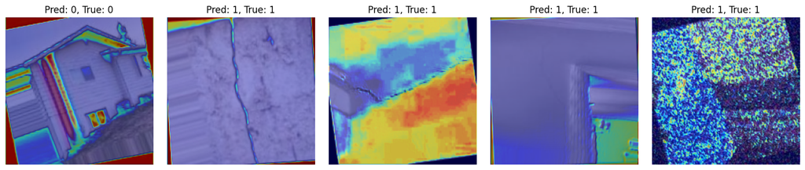

```
🔍 Custom CNN - Incorrect
```

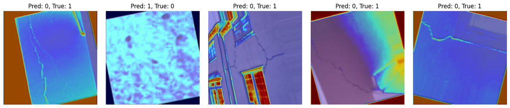

```python
model = CustomCNN()
model.load_state_dict(torch.load("custom_cnn_model.pth"))
run_gradcam(model, test_loader, model.model[0], "Custom CNN")
```

In this visualization, we apply Grad-CAM to interpret the decisions of our ResNet18 model. In the correct examples, we can see that the ResNet18 model generally concentrates on meaningful areas. For positive samples (cracks), the heatmaps often highlight the crack itself or the damaged region. For negative samples (no cracks), the attention tends to be spread out or focused on undamaged areas, suggesting that the model has learned to identify intact surfaces. In the incorrect examples, the heatmaps reveal some of the model's confusion. For all three cases here, the model predicted cracks where there were none (false positives). The attention maps indicate that the model was influenced by certain textures, patterns, or lighting variations in the image that it mistakenly associated with cracks.

```
🔍 ResNet18 - Correct
```

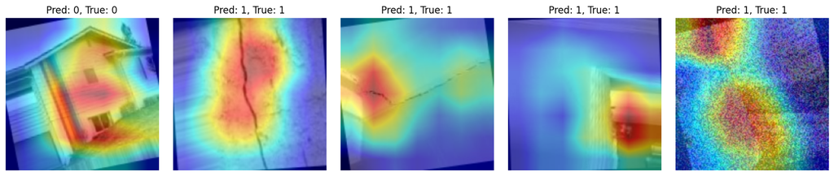

```
🔍 ResNet18 - Incorrect
```

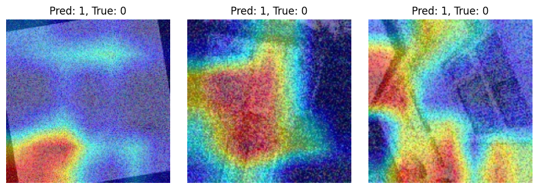

```python
resnet = models.resnet18()
resnet.fc = nn.Sequential(
    nn.Linear(resnet.fc.in_features, 128),
    nn.ReLU(),
    nn.Dropout(0.3),
    nn.Linear(128, NUM_CLASSES)
)
resnet.load_state_dict(torch.load("resnet18_transfer_model.pth"))
run_gradcam(resnet, test_loader, resnet.layer4[-1], "ResNet18")
```

In the correct predictions, the SE-enhanced CNN generally highlights relevant regions. For positive (crack) images, we see the model focusing on or near the crack lines, suggesting that the SE blocks are helping it emphasize important channels that correspond to crack patterns. For negative samples, the model focuses on larger structural regions or uniform surfaces, successfully identifying areas that are free of cracks. However, we can see the heatmaps are not emphasized meaning the model might be uncertain in most scenarios.

```
🔍 CNN with SE - Correct
```

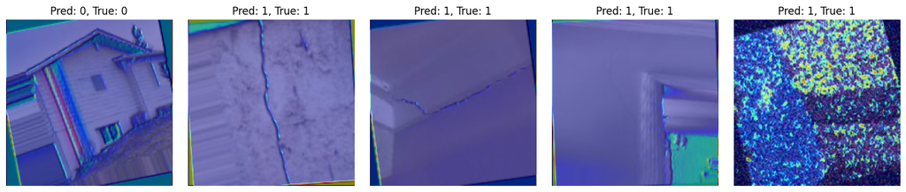

```
🔍 CNN with SE - Incorrect
```

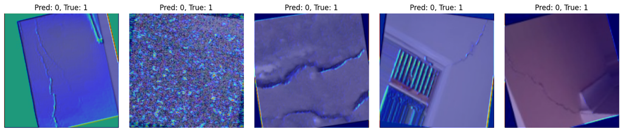

```python
se_model = CNNWithSE()
se_model.load_state_dict(torch.load("cnn_with_se_model.pth"))
run_gradcam(se_model, test_loader, se_model.conv1, "CNN with SE")
```

### Tile-based Approach

Now, we are going to see what the final result looks like with each one of the models. We are going to write the code again for the tile-based approach, as it is easier to run the notebook just in this section.

```python
import cv2
import numpy as np
import torch
import matplotlib.pyplot as plt
from torchvision import transforms
from typing import List, Tuple

def get_image_patches(img: np.ndarray, patch_size: int = 256, stride: int = 128) -> List[Tuple[Tuple[int, int], np.ndarray]]:
    patches = []
    h, w, _ = img.shape
    for y in range(0, h - patch_size + 1, stride):
        for x in range(0, w - patch_size + 1, stride):
            patch = img[y:y+patch_size, x:x+patch_size]
            patches.append(((x, y), patch))
    return patches

def preprocess_patch(patch):
    transform = transforms.Compose([
        transforms.ToPILImage(),
        transforms.Resize((224, 224)),
        transforms.ToTensor(),
        transforms.Normalize(mean=[0.485, 0.456, 0.406],
                             std=[0.229, 0.224, 0.225])
    ])
    return transform(patch).unsqueeze(0).to(DEVICE)
```

```python
def run_tile_based_inference(model, image_path: str, model_name: str, patch_size: int = 256, stride: int = 128):
    image = cv2.imread(image_path)
    image_rgb = cv2.cvtColor(image, cv2.COLOR_BGR2RGB)
    patches = get_image_patches(image, patch_size, stride)

    cracked_patches = []
    model.eval().to(DEVICE)

    for (x, y), patch in patches:
        input_patch = preprocess_patch(patch)
        with torch.no_grad():
            output = model(input_patch)
            pred_class = torch.argmax(output, dim=1).item()

        if pred_class == 1:
            cracked_patches.append((x, y))

    print(f"✅ {model_name}: {len(cracked_patches)} cracked patches detected out of {len(patches)}.")

    image_with_boxes = image_rgb.copy()
    for (x, y) in cracked_patches:
        cv2.rectangle(image_with_boxes, (x, y), (x + patch_size, y + patch_size), (255, 0, 0), 3)

    plt.figure(figsize=(10, 10))
    plt.imshow(image_with_boxes)
    plt.title(f"{model_name} Detection Result: {len(cracked_patches)} cracked patches")
    plt.axis("off")
    plt.show()
```

We are going to use the same internet image as before to evaluate the models. The reasoning behind this image is that it does not contain just a crack, so we can see if the model is performing well. Also, this image is high resolution and can be divided into many patches (such images are going to be used from the drone).

```
✅ Custom CNN: 640 cracked patches detected out of 660.
```

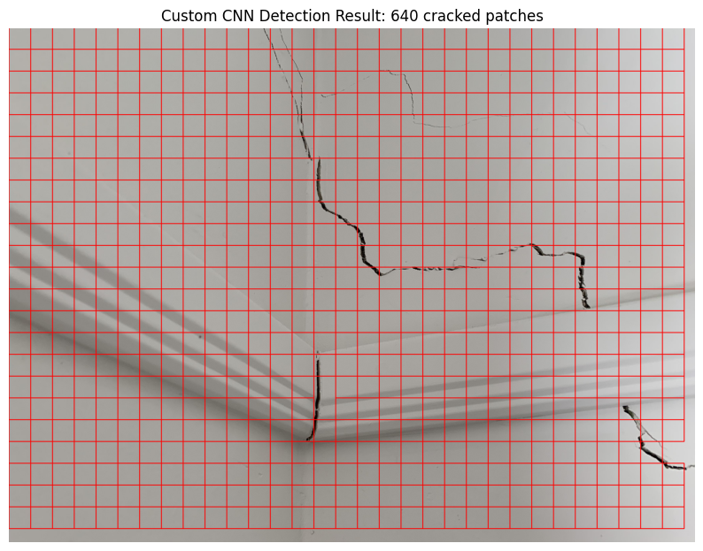

```
✅ ResNet: 250 cracked patches detected out of 660.
```

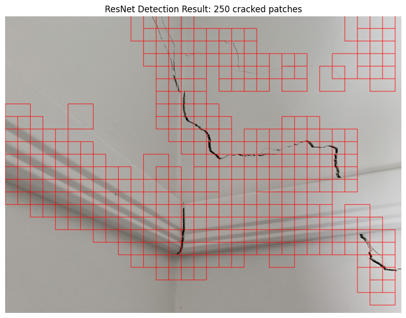

```
✅ AttentionNet: 80 cracked patches detected out of 660.
```

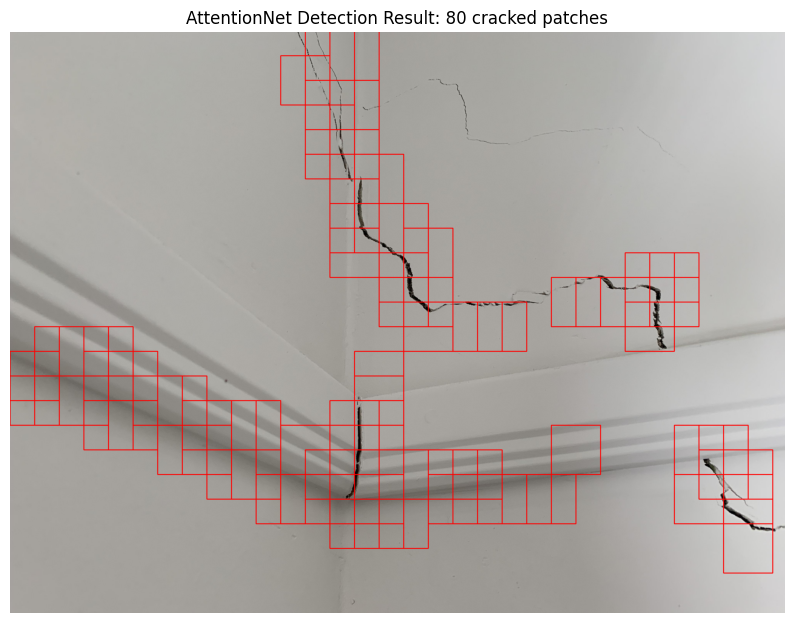

```
✅ ViT: 97 cracked patches detected out of 660.
```

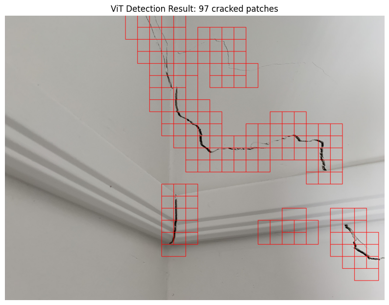

```python
test_image_path = "test4.jpg"

run_tile_based_inference(custom_model, test_image_path, model_name="Custom CNN")
run_tile_based_inference(resnet, test_image_path, model_name="ResNet")
run_tile_based_inference(se_model, test_image_path, model_name="AttentionNet")
run_tile_based_inference(vit_model, test_image_path, model_name="ViT")
```

The Custom CNN model produced highly sensitive results, detecting cracks in nearly all patches of the image. This lead to too many false positives. The model has good evaluation metrics and good decrease of the loss during epochs on training, but the final and most important evaluation showed that it did not learn well from the data and it is not suitable for our project.

The CNN with SE (Squeeze-and-Excitation) model took a conservative approach. It detected cracks in fewer patches, focusing primarily on regions with strong crack signals.

Through this evaluation, we can see that the ViT model performed the best even capturing cracks that are sensitive to the human eye.

### Ensemble Model

In this last part of the project regarding the classification models, we designed and implemented an ensemble model combining the strengths of two different architectures: the custom-trained CNN model that we had before and the Vision Transformer (ViT) model. The goal was to leverage both models’ unique abilities — the CNN’s sensitivity to fine details and textures, and the ViT’s global contextual understanding — to produce a more reliable crack detection system.

We began by defining a tile-based inference pipeline. Since large images are challenging to process in full resolution by deep learning models, we split the input image into overlapping tiles (patches) of size 256×256 pixels, sliding with a stride of 128 pixels. This ensures good coverage and overlap so that cracks spanning multiple tiles are detected without gaps.

For each patch, we independently processed it through both models:

- The CNN model received patches resized to 128×128 pixels and normalized between 0 and 1.
- The ViT model received patches resized to 224×224 pixels, normalized using ImageNet statistics to match its pretraining.

Each model produced a probability that the patch contained a crack. We averaged these probabilities to compute the final ensemble prediction. If this probability was greater than 0.5, the patch was classified as cracked.

We then visualized the results in two ways:

- Final image overlay: The original image was displayed with red bounding boxes highlighting all patches predicted as cracked by the ensemble model. This provides an immediate understanding of where cracks were detected spatially across the structure.
- Patch display: We presented a grid of the actual cracked patches detected, allowing for closer inspection of the regions the model flagged. This helps us validate if the predictions correspond to true crack regions or false positives.

Overall, this ensemble approach helped balance sensitivity and precision, improving detection robustness compared to using either model alone. The tile-based method ensures cracks are localized effectively, even on high-resolution, complex images.

```python
import cv2
import numpy as np
import torch
import matplotlib.pyplot as plt
from torchvision import transforms
from tensorflow.keras.models import load_model
from PIL import Image
from typing import List, Tuple

DEVICE = torch.device("cuda" if torch.cuda.is_available() else "cpu")

cnn_model = load_model("cnn_crack_model.h5")
vit_model.eval().to(DEVICE)
```

```python
def get_image_patches(img: np.ndarray, patch_size: int = 256, stride: int = 128) -> List[Tuple[Tuple[int, int], np.ndarray]]:
    patches = []
    h, w, _ = img.shape
    for y in range(0, h - patch_size + 1, stride):
        for x in range(0, w - patch_size + 1, stride):
            patch = img[y:y+patch_size, x:x+patch_size]
            patches.append(((x, y), patch))
    return patches

def preprocess_cnn_patch(patch):
    patch_resized = cv2.resize(patch, (128, 128))
    patch_normalized = patch_resized / 255.0
    return np.expand_dims(patch_normalized, axis=0)

vit_transform = transforms.Compose([
    transforms.ToPILImage(),
    transforms.Resize((224, 224)),
    transforms.ToTensor(),
    transforms.Normalize(mean=[0.485, 0.456, 0.406],
                         std=[0.229, 0.224, 0.225])
])

def preprocess_vit_patch(patch):
    return vit_transform(patch).unsqueeze(0).to(DEVICE)
```

```python
def ensemble_predict(patch):
    cnn_input = preprocess_cnn_patch(patch)
    cnn_prob = cnn_model.predict(cnn_input)[0][0]

    vit_input = preprocess_vit_patch(patch)
    with torch.no_grad():
        vit_output = vit_model(vit_input)
        vit_prob = torch.softmax(vit_output, dim=1)[0][1].item()

    final_prob = (cnn_prob + vit_prob) / 2
    final_class = 1 if final_prob > 0.5 else 0

    return final_class, final_prob
```

```python
def display_cracked_patches(crack_patches, image, patch_size):
    if not crack_patches:
        print("⚠️ No cracked patches detected.")
        return

    cols = 5
    rows = (len(crack_patches) + cols - 1) // cols

    plt.figure(figsize=(15, 3 * rows))
    for idx, (x, y) in enumerate(crack_patches):
        patch = image[y:y+patch_size, x:x+patch_size]
        patch_rgb = cv2.cvtColor(patch, cv2.COLOR_BGR2RGB)
        plt.subplot(rows, cols, idx + 1)
        plt.imshow(patch_rgb)
        plt.title(f"({x},{y})")
        plt.axis("off")
    plt.tight_layout()
    plt.show()

def run_ensemble_tile_inference(image_path: str, patch_size: int = 256, stride: int = 128):
    image_bgr = cv2.imread(image_path)
    if image_bgr is None:
        print(f"❌ Could not load image at {image_path}")
        return
    image_rgb = cv2.cvtColor(image_bgr, cv2.COLOR_BGR2RGB)

    patches = get_image_patches(image_bgr, patch_size, stride)
    print(f"🔍 Extracted {len(patches)} patches from image.")

    crack_patches = []
    for (x, y), patch in patches:
        pred_class, prob = ensemble_predict(patch)
        if pred_class == 1:
            crack_patches.append((x, y))

    print(f"✅ Ensemble detected cracks in {len(crack_patches)} / {len(patches)} patches.")

    image_with_boxes = image_rgb.copy()
    for (x, y) in crack_patches:
        cv2.rectangle(image_with_boxes, (x, y), (x + patch_size, y + patch_size), (255, 0, 0), 3)

    plt.figure(figsize=(10, 10))
    plt.imshow(image_with_boxes)
    plt.title(f"Ensemble Detection: {len(crack_patches)} cracked patches")
    plt.axis("off")
    plt.show()

    display_cracked_patches(crack_patches, image_bgr, patch_size)
```

```
🔍 Extracted 660 patches from image.
✅ Ensemble detected cracks in 88 / 660 patches.
```

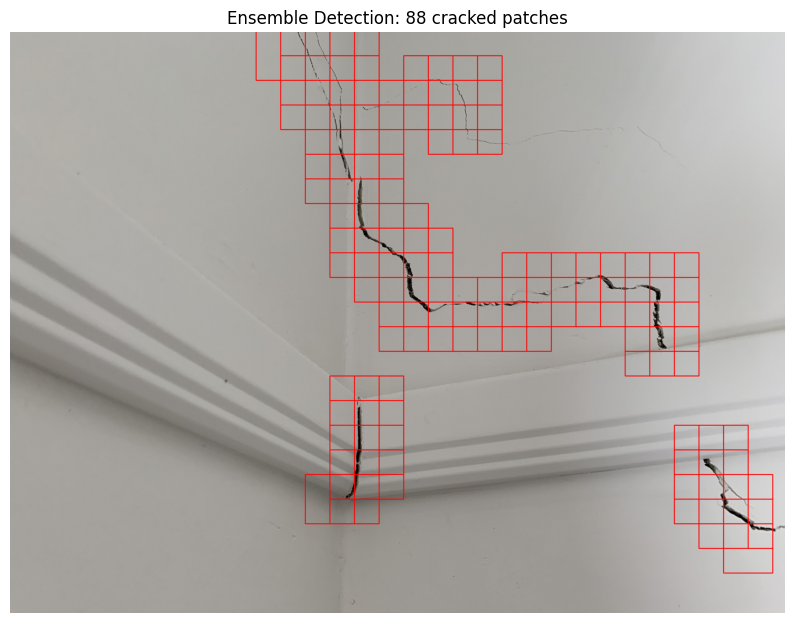

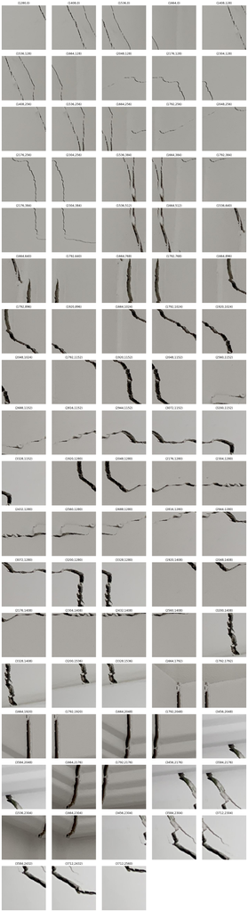

```python
test_image_path = "test4.jpg"
run_ensemble_tile_inference(test_image_path)
```

As we can see the ensemble model perforfmed extremely well and we were able to inspect all of the patches that are marked as cracked and indeed they have a crack.

### Quantization and Speed Optimization

To reduce model size and inference time, we applied post-training dynamic quantization to the ViT model, as it is the largest and one of the best performing ones. We compared the size and speed of the quantized model against the original float32 model.

```python
import torch.quantization
import os

vit_quantized = torch.quantization.quantize_dynamic(
    vit_model, {torch.nn.Linear}, dtype=torch.qint8
)

torch.save(vit_model.state_dict(), "vit_fp32.pth")
torch.save(vit_quantized.state_dict(), "vit_int8.pth")

fp32_size = os.path.getsize("vit_fp32.pth") / 1e6
int8_size = os.path.getsize("vit_int8.pth") / 1e6

print(f"FP32 size: {fp32_size:.2f} MB")
print(f"INT8 size: {int8_size:.2f} MB")
```

```
FP32 size: 343.65 MB
INT8 size: 88.58 MB
```

Quantization significantly reduced the model size and provided a small boost in inference speed. These benefits can be crucial for deployment on edge devices, mobile applications, or servers where memory and compute resources are constrained.

```python
import time

def measure_inference_speed(model, example_input, n_runs=100):
    model.eval()
    with torch.no_grad():
        start = time.time()
        for _ in range(n_runs):
            _ = model(example_input)
        end = time.time()
    avg_time = (end - start) / n_runs
    print(f"Avg inference time: {avg_time*1000:.2f} ms")

example_input = torch.randn(1, 3, 224, 224).to(DEVICE)

print("Original ViT:")
measure_inference_speed(vit_model, example_input)

print("Quantized ViT:")
measure_inference_speed(vit_quantized, example_input.cpu())
```

```
Original ViT:
Avg inference time: 133.71 ms
Quantized ViT:
Avg inference time: 99.41 ms
```

In this section, we optimized the tile-based ensemble inference by introducing batching during prediction. Previously, each patch was processed individually, which increased computation time due to repeated model calls and data movement between CPU and GPU. With batching, we group multiple patches (e.g., 16 at a time) and pass them through both the CNN and ViT models in a single forward pass. This significantly improves efficiency and reduces latency, especially when running on hardware that benefits from parallelization, such as GPUs.

We updated the preprocessing functions to handle batches. For the CNN, patches are resized and normalized together and converted into a single NumPy array. For the ViT, patches are transformed into tensors, stacked, and moved as a batch to the appropriate device (CPU or GPU). During inference, we compute the predictions for the entire batch at once for both models, average their probabilities, and determine which patches contain cracks. The results are then visualized with red boxes marking detected crack regions.

```python
import cv2
import numpy as np
import torch
import matplotlib.pyplot as plt
from tensorflow.keras.models import load_model
from torchvision import transforms
from typing import List, Tuple

DEVICE = torch.device("cuda" if torch.cuda.is_available() else "cpu")

cnn_model = load_model("cnn_crack_model.h5")
vit_model.eval().to(DEVICE)

def get_image_patches(img: np.ndarray, patch_size: int = 256, stride: int = 128) -> List[Tuple[Tuple[int, int], np.ndarray]]:
    patches = []
    h, w, _ = img.shape
    for y in range(0, h - patch_size + 1, stride):
        for x in range(0, w - patch_size + 1, stride):
            patch = img[y:y+patch_size, x:x+patch_size]
            patches.append(((x, y), patch))
    return patches

def preprocess_cnn_batch(patch_list):
    resized = [cv2.resize(p, (128, 128)) / 255.0 for p in patch_list]
    return np.array(resized)

vit_transform = transforms.Compose([
    transforms.ToPILImage(),
    transforms.Resize((224, 224)),
    transforms.ToTensor(),
    transforms.Normalize(mean=[0.485, 0.456, 0.406],
                         std=[0.229, 0.224, 0.225])
])

def preprocess_vit_batch(patch_list):
    tensors = [vit_transform(p).unsqueeze(0) for p in patch_list]
    return torch.cat(tensors).to(DEVICE)

def run_ensemble_tile_inference_batched(image_path: str, patch_size: int = 256, stride: int = 128, batch_size: int = 16):
    image_bgr = cv2.imread(image_path)
    if image_bgr is None:
        print(f"❌ Could not load image at {image_path}")
        return
    image_rgb = cv2.cvtColor(image_bgr, cv2.COLOR_BGR2RGB)

    patches = get_image_patches(image_bgr, patch_size, stride)
    locations = [loc for loc, _ in patches]
    patch_data = [patch for _, patch in patches]

    print(f"🔍 Extracted {len(patches)} patches.")

    crack_patches = []

    for i in range(0, len(patch_data), batch_size):
        batch_patches = patch_data[i:i+batch_size]
        batch_locs = locations[i:i+batch_size]

        cnn_input = preprocess_cnn_batch(batch_patches)
        cnn_probs = cnn_model.predict(cnn_input).flatten()

        vit_input = preprocess_vit_batch(batch_patches)
        with torch.no_grad():
            vit_output = vit_model(vit_input)
            vit_probs = torch.softmax(vit_output, dim=1)[:, 1].cpu().numpy()

        avg_probs = (cnn_probs + vit_probs) / 2
        for (x, y), prob in zip(batch_locs, avg_probs):
            if prob > 0.5:
                crack_patches.append((x, y))

    print(f"✅ Detected cracks in {len(crack_patches)} / {len(patches)} patches.")

    image_with_boxes = image_rgb.copy()
    for (x, y) in crack_patches:
        cv2.rectangle(image_with_boxes, (x, y), (x + patch_size, y + patch_size), (255, 0, 0), 3)

    plt.figure(figsize=(10, 10))
    plt.imshow(image_with_boxes)
    plt.title(f"Ensemble Detection (Batched): {len(crack_patches)} cracked patches")
    plt.axis("off")
    plt.show()

    if crack_patches:
        cols = 5
        rows = (len(crack_patches) + cols - 1) // cols
        plt.figure(figsize=(15, 3 * rows))
        for idx, (x, y) in enumerate(crack_patches):
            patch = image_bgr[y:y+patch_size, x:x+patch_size]
            patch_rgb = cv2.cvtColor(patch, cv2.COLOR_BGR2RGB)
            plt.subplot(rows, cols, idx + 1)
            plt.imshow(patch_rgb)
            plt.title(f"({x},{y})")
            plt.axis("off")
        plt.tight_layout()
        plt.show()
    else:
        print("⚠️ No cracked patches detected.")
```

```
🔍 Extracted 660 patches.
✅ Detected cracks in 88 / 660 patches.
```

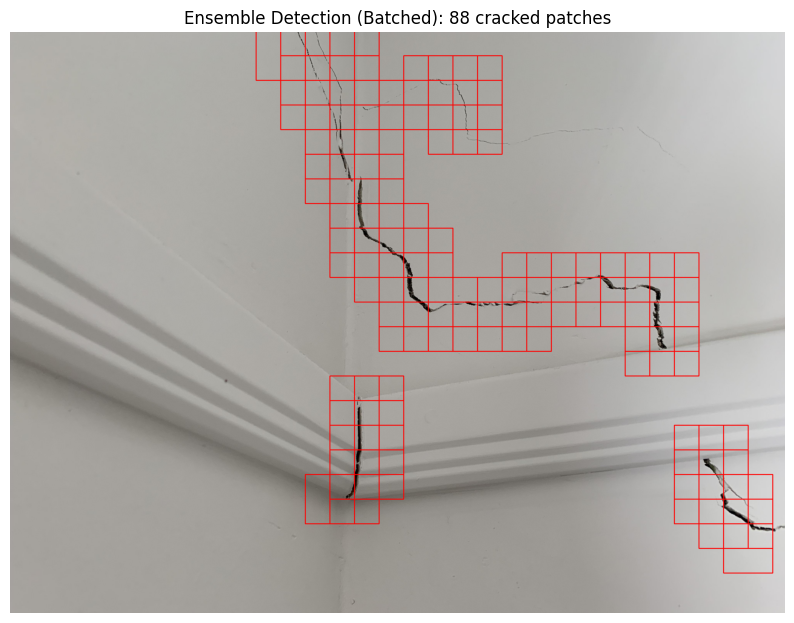

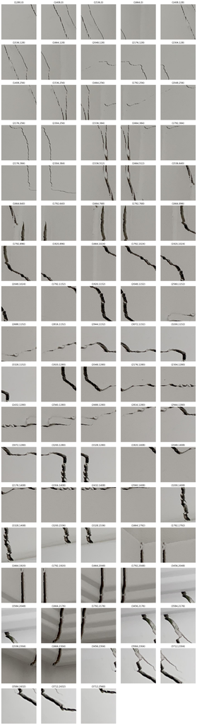

```python
test_image_path = "test4.jpg"
run_ensemble_tile_inference_batched(test_image_path, batch_size=16)
```

## Masking

```python
import os
import cv2
import numpy as np
from torch.utils.data import Dataset

class SegmentationDataset(Dataset):
    def __init__(self, image_dir, mask_dir, transform=None):
        self.image_dir = image_dir
        self.mask_dir = mask_dir
        self.transform = transform
        self.images = os.listdir(image_dir)

    def __len__(self):
        return len(self.images)

    def __getitem__(self, idx):
        img_path = os.path.join(self.image_dir, self.images[idx])
        mask_path = os.path.join(self.mask_dir, self.images[idx])

        image = cv2.imread(img_path)
        mask = cv2.imread(mask_path, cv2.IMREAD_GRAYSCALE)

        image = cv2.resize(image, (256, 256))
        mask = cv2.resize(mask, (256, 256))

        if self.transform:
            augmented = self.transform(image=image, mask=mask)
            image = augmented['image']
            mask = augmented['mask']

        return image, mask
```

```python
import torch
import torch.nn as nn

class UNet(nn.Module):
    def __init__(self, in_channels=3, out_channels=1):
        super(UNet, self).__init__()
        self.encoder = nn.Sequential(
            nn.Conv2d(in_channels, 64, 3, padding=1),
            nn.ReLU(),
            nn.Conv2d(64, 64, 3, padding=1),
            nn.ReLU(),
            nn.MaxPool2d(2)
        )
        self.middle = nn.Sequential(
            nn.Conv2d(64, 128, 3, padding=1),
            nn.ReLU(),
            nn.Conv2d(128, 128, 3, padding=1),
            nn.ReLU(),
        )
        self.decoder = nn.Sequential(
            nn.ConvTranspose2d(128, 64, kernel_size=2, stride=2),
            nn.ReLU(),
            nn.Conv2d(64, 64, 3, padding=1),
            nn.ReLU(),
            nn.Conv2d(64, out_channels, 1)
        )

    def forward(self, x):
        enc = self.encoder(x)
        middle = self.middle(enc)
        dec = self.decoder(middle)
        return dec
```

```python
import os
import numpy as np
import matplotlib.pyplot as plt
from PIL import Image
from sklearn.model_selection import train_test_split
from tensorflow.keras.models import Model
from tensorflow.keras.layers import Input, Conv2D, MaxPooling2D, Conv2DTranspose, concatenate
from tensorflow.keras.optimizers import Adam
import tensorflow as tf
import cv2

IMG_HEIGHT = 256
IMG_WIDTH = 256
IMG_CHANNELS = 3
POSITIVE_DIR = r"final_dataset/positive"
NEGATIVE_DIR = r"final_dataset/negative"

def generate_mask(image):
    gray = cv2.cvtColor(image, cv2.COLOR_RGB2GRAY)
    blurred = cv2.GaussianBlur(gray, (5, 5), 0)
    thresh = cv2.adaptiveThreshold(blurred, 255, cv2.ADAPTIVE_THRESH_GAUSSIAN_C,
                                   cv2.THRESH_BINARY_INV, 11, 2)
    kernel = np.ones((3, 3), np.uint8)
    morph = cv2.morphologyEx(thresh, cv2.MORPH_CLOSE, kernel, iterations=2)
    return morph

def load_data(pos_dir, neg_dir):
    pos_files = sorted([os.path.join(pos_dir, f) for f in os.listdir(pos_dir)])
    neg_files = sorted([os.path.join(neg_dir, f) for f in os.listdir(neg_dir)])

    images = []
    masks = []

    for img_path in pos_files:
        img = Image.open(img_path).resize((IMG_WIDTH, IMG_HEIGHT))
        img_np = np.array(img)
        if img_np.shape[-1] == 4:
            img_np = img_np[:, :, :3]
        img_np = cv2.resize(img_np, (IMG_WIDTH, IMG_HEIGHT))
        mask = generate_mask(img_np)

        images.append(img_np / 255.0)
        masks.append(mask[..., np.newaxis] / 255.0)

    for img_path in neg_files:
        img = Image.open(img_path).resize((IMG_WIDTH, IMG_HEIGHT))
        img_np = np.array(img)
        if img_np.shape[-1] == 4:
            img_np = img_np[:, :, :3]
        img_np = cv2.resize(img_np, (IMG_WIDTH, IMG_HEIGHT))
        blank_mask = np.zeros((IMG_HEIGHT, IMG_WIDTH, 1))

        images.append(img_np / 255.0)
        masks.append(blank_mask)

    return np.array(images), np.array(masks)

# --- U-NET MODEL ---
def build_unet():
    inputs = Input((IMG_HEIGHT, IMG_WIDTH, IMG_CHANNELS))

    c1 = Conv2D(16, (3, 3), activation='relu', padding='same')(inputs)
    c1 = Conv2D(16, (3, 3), activation='relu', padding='same')(c1)
    p1 = MaxPooling2D((2, 2))(c1)

    c2 = Conv2D(32, (3, 3), activation='relu', padding='same')(p1)
    c2 = Conv2D(32, (3, 3), activation='relu', padding='same')(c2)
    p2 = MaxPooling2D((2, 2))(c2)

    c3 = Conv2D(64, (3, 3), activation='relu', padding='same')(p2)
    c3 = Conv2D(64, (3, 3), activation='relu', padding='same')(c3)
    p3 = MaxPooling2D((2, 2))(c3)

    c4 = Conv2D(128, (3, 3), activation='relu', padding='same')(p3)
    c4 = Conv2D(128, (3, 3), activation='relu', padding='same')(c4)

    u5 = Conv2DTranspose(64, (2, 2), strides=(2, 2), padding='same')(c4)
    u5 = concatenate([u5, c3])
    c5 = Conv2D(64, (3, 3), activation='relu', padding='same')(u5)
    c5 = Conv2D(64, (3, 3), activation='relu', padding='same')(c5)

    u6 = Conv2DTranspose(32, (2, 2), strides=(2, 2), padding='same')(c5)
    u6 = concatenate([u6, c2])
    c6 = Conv2D(32, (3, 3), activation='relu', padding='same')(u6)
    c6 = Conv2D(32, (3, 3), activation='relu', padding='same')(c6)

    u7 = Conv2DTranspose(16, (2, 2), strides=(2, 2), padding='same')(c6)
    u7 = concatenate([u7, c1])
    c7 = Conv2D(16, (3, 3), activation='relu', padding='same')(u7)
    c7 = Conv2D(16, (3, 3), activation='relu', padding='same')(c7)

    outputs = Conv2D(1, (1, 1), activation='sigmoid')(c7)

    model = Model(inputs=[inputs], outputs=[outputs])
    return model

X, Y = load_data(POSITIVE_DIR, NEGATIVE_DIR)
X_train, X_val, Y_train, Y_val = train_test_split(X, Y, test_size=0.1, random_state=42)

model = build_unet()
model.compile(optimizer=Adam(), loss='binary_crossentropy', metrics=['accuracy'])

history = model.fit(X_train, Y_train, validation_data=(X_val, Y_val), batch_size=8, epochs=20)

def plot_sample(X, Y, preds, index):
    plt.figure(figsize=(12, 4))
    plt.subplot(1, 3, 1)
    plt.title("Image")
    plt.imshow(X[index])
    plt.axis('off')

    plt.subplot(1, 3, 2)
    plt.title("Generated Mask")
    plt.imshow(Y[index].squeeze(), cmap='gray')
    plt.axis('off')

    plt.subplot(1, 3, 3)
    plt.title("Prediction")
    plt.imshow(preds[index].squeeze() > 0.5, cmap='gray')
    plt.axis('off')
    plt.show()

preds = model.predict(X_val)
plot_sample(X_val, Y_val, preds, index=0)
```

```python
MODEL_PATH = "crack_unet_model.h5"

model.save(MODEL_PATH)
```

```python
from tensorflow.keras.models import Model, load_model
import random

def load_data(pos_dir, neg_dir):
    pos_files = sorted([os.path.join(pos_dir, f) for f in os.listdir(pos_dir)])
    neg_files = sorted([os.path.join(neg_dir, f) for f in os.listdir(neg_dir)])

    images = []
    masks = []

    for img_path in pos_files:
        img = Image.open(img_path).resize((IMG_WIDTH, IMG_HEIGHT))
        img_np = np.array(img)
        if img_np.shape[-1] == 4:
            img_np = img_np[:, :, :3]
        img_np = cv2.resize(img_np, (IMG_WIDTH, IMG_HEIGHT))
        mask = generate_mask(img_np)

        images.append(img_np / 255.0)
        masks.append(mask[..., np.newaxis] / 255.0)

    for img_path in neg_files:
        img = Image.open(img_path).resize((IMG_WIDTH, IMG_HEIGHT))
        img_np = np.array(img)
        if img_np.shape[-1] == 4:
            img_np = img_np[:, :, :3]
        img_np = cv2.resize(img_np, (IMG_WIDTH, IMG_HEIGHT))
        blank_mask = np.zeros((IMG_HEIGHT, IMG_WIDTH, 1))

        images.append(img_np / 255.0)
        masks.append(blank_mask)

    return np.array(images), np.array(masks), pos_files, neg_files

def test_random_images(model, pos_files, neg_files):
    sample_paths = [random.choice(pos_files), random.choice(neg_files)]
    titles = ["Positive Sample", "Negative Sample"]

    for path, title in zip(sample_paths, titles):
        img = Image.open(path).resize((IMG_WIDTH, IMG_HEIGHT))
        img_np = np.array(img)
        if img_np.shape[-1] == 4:
            img_np = img_np[:, :, :3]
        img_np = cv2.resize(img_np, (IMG_WIDTH, IMG_HEIGHT))

        mask = generate_mask(img_np)
        input_tensor = np.expand_dims(img_np / 255.0, axis=0)
        pred_mask = model.predict(input_tensor)[0, :, :, 0] > 0.5

        plt.figure(figsize=(12, 4))
        plt.suptitle(title)

        plt.subplot(1, 3, 1)
        plt.title("Image")
        plt.imshow(img_np / 255.0)
        plt.axis('off')

        plt.subplot(1, 3, 2)
        plt.title("Generated Mask")
        plt.imshow(mask, cmap='gray')
        plt.axis('off')

        plt.subplot(1, 3, 3)
        plt.title("Prediction")
        plt.imshow(pred_mask, cmap='gray')
        plt.axis('off')

        plt.show()
X, Y, pos_files, neg_files = load_data(POSITIVE_DIR, NEGATIVE_DIR)

model = load_model(MODEL_PATH)
test_random_images(model, pos_files, neg_files)
```

### LCW dataset

For the this part of the Crack segmentation, we are taking a LCW dataset which contains normal image with either a crack or not and the corresponding mask which can be either black or black with the white outline of the mask. The class takes in directories for both images and masks, filters out any image-mask pairs where the mask is completely empty (i.e., contains no cracks), and only retains valid pairs for training. When accessing an item, it loads the RGB image and its corresponding grayscale mask, applies optional image and mask transformations (such as resizing or normalization), and ensures the mask is binarized (i.e., pixels are set to 1 where cracks exist, 0 otherwise). This setup is used to train a model to learn the relationship between the input image and the presence of cracks as indicated by the mask, effectively allowing the model to predict crack locations from new images.

```python
import os
from PIL import Image
import torch
from torch.utils.data import Dataset
from torchvision import transforms
import numpy as np
from PIL import Image
class CrackDataset(Dataset):
    def __init__(self, image_dir, mask_dir, image_transform=None, mask_transform=None):
        self.image_dir = image_dir
        self.mask_dir = mask_dir
        self.image_transform = image_transform
        self.mask_transform = mask_transform

        all_images = sorted([
            f for f in os.listdir(image_dir)
            if f.lower().endswith(('.png', '.jpg', '.jpeg'))
        ])

        mask_files = {
            os.path.splitext(f)[0]: f
            for f in os.listdir(mask_dir)
            if f.lower().endswith(('.png', '.bmp', '.tif'))
        }

        self.valid_pairs = []
        for img_file in all_images:
            base = os.path.splitext(img_file)[0]
            if base in mask_files:
                mask_path = os.path.join(mask_dir, mask_files[base])
                mask = Image.open(mask_path).convert("L")
                if np.array(mask).max() > 0:  # Check if mask has cracks
                    self.valid_pairs.append((img_file, mask_files[base]))

        print(f"Loaded {len(self.valid_pairs)} valid image-mask pairs (non-empty masks only).")

    def __len__(self):
        return len(self.valid_pairs)

    def __getitem__(self, idx):
        img_filename, mask_filename = self.valid_pairs[idx]

        img_path = os.path.join(self.image_dir, img_filename)
        mask_path = os.path.join(self.mask_dir, mask_filename)

        image = Image.open(img_path).convert("RGB")
        mask = Image.open(mask_path).convert("L")

        if self.image_transform:
            image = self.image_transform(image)
        if self.mask_transform:
            mask = self.mask_transform(mask)

        mask = (mask > 0).float()
        return image, mask
```

Now that we've defined our image_transform and mask_transform, we're setting up preprocessing and data augmentation pipelines for both the input images and their corresponding masks to prepare them for training a deep learning model.

```python
from torchvision import transforms

image_transform = transforms.Compose([
    transforms.Resize((256, 256)),
    transforms.RandomHorizontalFlip(),
    transforms.ColorJitter(brightness=0.2, contrast=0.2),
    transforms.ToTensor(),
    transforms.Normalize([0.5, 0.5, 0.5], [0.5, 0.5, 0.5])  # For RGB
])

mask_transform = transforms.Compose([
    transforms.Resize((256, 256)),
    transforms.ToTensor(),  # Converts [0,255] -> [0.0, 1.0], shape [1, H, W]
])
```

#### U-Net

We are now creating U_net model which is a popu;ar architecture for semantic segmentation tasks like crack detection.With this, you're ready to move on to defining a training loop where this model will take input images from your CrackDataset, predict the mask, and compare it with the ground-truth mask to learn how to segment cracks.

```python
##############UNCOMMENT WHEN NO SAVED MODEL EXISTS

# import segmentation_models_pytorch as smp

# model = smp.Unet(
#     encoder_name="resnet34",
#     encoder_weights="imagenet",
#     in_channels=3,
#     classes=1,
#     activation=None
# )
# device = torch.device("cpu")
# model = model.to(device)
```

Now we are defining the training loop for the crack segmentation model.

```python
##############UNCOMMENT WHEN NO SAVED MODEL EXISTS
# from torch.utils.data import DataLoader
# import torch.nn as nn
# import torch.optim as optim
# train_dataset = CrackDataset(
#     r"C:\Users\denic\Downloads\16624672\LCW Concrete Crack Detection\LCW Concrete Crack Detection\512x512\Train\images",
#     r"C:\Users\denic\Downloads\16624672\LCW Concrete Crack Detection\LCW Concrete Crack Detection\512x512\Train\masks",
#     image_transform=image_transform,
#     mask_transform=mask_transform
# )

# train_loader = DataLoader(train_dataset, batch_size=8, shuffle=True)

# criterion = nn.BCEWithLogitsLoss()
# optimizer = optim.Adam(model.parameters(), lr=1e-4)

# for epoch in range(5):
#     model.train()
#     epoch_loss = 0
#     for images, masks in train_loader:
#         images = images.to(device)
#         masks = masks.to(device)


#         optimizer.zero_grad()
#         outputs = model(images)
#         loss = criterion(outputs, masks)
#         loss.backward()
#         optimizer.step()

#         epoch_loss += loss.item()
#     print(f"Epoch {epoch+1} - Loss: {epoch_loss / len(train_loader):.4f}")
```

```python
torch.save(model.state_dict(), "unet_crack_segmentation1.pth")
```

### Evaluation

It assesses how well the model is segmenting cracks by calculating:

- Average loss (how close predictions are to the ground truth masks)
- Average Dice score (a metric for overlap between predicted and true masks)

```python
def evaluate_model(model, data_loader, device, criterion, threshold=0.1):
    model.eval()
    total_loss = 0.0
    total_dice = 0.0
    num_batches = 0

    with torch.no_grad():
        for images, masks in data_loader:
            images = images.to(device)
            masks = masks.to(device)

            outputs = model(images)
            loss = criterion(outputs, masks)
            total_loss += loss.item()

            preds = torch.sigmoid(outputs)
            preds = (preds > threshold).float()
            intersection = (preds * masks).sum(dim=(1, 2, 3))
            union = preds.sum(dim=(1, 2, 3)) + masks.sum(dim=(1, 2, 3))
            dice = (2 * intersection / (union + 1e-8)).mean().item()

            total_dice += dice
            num_batches += 1

    avg_loss = total_loss / num_batches
    avg_dice = total_dice / num_batches
    print(f"\nEvaluation - Loss: {avg_loss:.4f}, Dice Score: {avg_dice:.4f}")
```

```python
import segmentation_models_pytorch as smp
import torch

model = smp.Unet(
    encoder_name="resnet34",
    encoder_weights="imagenet",
    in_channels=3,
    classes=1,
    activation=None
)

device = torch.device("cuda" if torch.cuda.is_available() else "cpu")
model = model.to(device)

model.load_state_dict(torch.load("unet_crack_segmentation1.pth", map_location=device))
model.eval()
```

[output not shown]

[output cut: 187 more lines]

[output not shown]

```python
from torch.utils.data import DataLoader
from torch.utils.data import DataLoader
import torch.nn as nn
import torch.optim as optim
train_dataset = CrackDataset(
    r"16624672/LCW Concrete Crack Detection/LCW Concrete Crack Detection/512x512/Train/images",
    r"16624672/LCW Concrete Crack Detection/LCW Concrete Crack Detection/512x512/Train/masks",
    image_transform=image_transform,
    mask_transform=mask_transform
)

train_loader = DataLoader(train_dataset, batch_size=8, shuffle=True)

criterion = nn.BCEWithLogitsLoss()
optimizer = optim.Adam(model.parameters(), lr=1e-4)
evaluate_model(model, train_loader, device, criterion)
```

```
Loaded 868 valid image-mask pairs (non-empty masks only).

Evaluation - Loss: 0.0510, Dice Score: 0.0974
```

The show_prediction function provides a visual insight into how well the trained model is segmenting cracks in the input images.This side-by-side comparison is crucial for qualitatively evaluating the model’s performance and helps identify strengths or failure cases in segmentation, such as under- or over-predicting crack regions. It also prints out statistics about the prediction values, aiding in understanding how confident the model is overall.

```python
import matplotlib.pyplot as plt
import random

def show_prediction(model, dataset, index=None, threshold=0.1):
    model.eval()

    if index is None:
        index = random.randint(0, len(dataset) - 1)

    image, true_mask = dataset[index]

    with torch.no_grad():
        input_tensor = image.unsqueeze(0).to(device)  # [1, C, H, W]
        output = model(input_tensor)                  # [1, 1, H, W]
        prob_mask = torch.sigmoid(output).squeeze().cpu().numpy()  # [H, W]

    print(f"Prediction min: {prob_mask.min():.4f}, max: {prob_mask.max():.4f}, mean: {prob_mask.mean():.4f}")

    pred_mask = (prob_mask > threshold).astype(float)
    true_mask = true_mask.squeeze().numpy()
    image = image.permute(1, 2, 0).numpy()  # Convert [C, H, W] -> [H, W, C]
    image = (image * 0.5 + 0.5).clip(0, 1)  # Denormalize

    plt.figure(figsize=(15, 4))
    plt.subplot(1, 4, 1)
    plt.title("Input Image")
    plt.imshow(image)
    plt.axis("off")

    plt.subplot(1, 4, 2)
    plt.title("True Mask")
    plt.imshow(true_mask, cmap='gray')
    plt.axis("off")

    plt.subplot(1, 4, 3)
    plt.title("Predicted Probabilities")
    plt.imshow(prob_mask, cmap='gray')
    plt.colorbar()
    plt.axis("off")

    plt.subplot(1, 4, 4)
    plt.title(f"Predicted Mask (>{threshold})")
    plt.imshow(pred_mask, cmap='gray')
    plt.axis("off")

    plt.tight_layout()
    plt.show()
```

```
Prediction min: 0.0001, max: 0.1908, mean: 0.0088
```

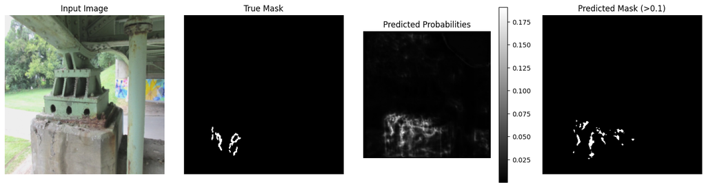

```python
show_prediction(model, train_dataset)
```

```python
image_dir = r"16624672/LCW Concrete Crack Detection/LCW Concrete Crack Detection/512x512/Train/images",
```

```python
##############UNCOMMENT WHEN NO SAVED MODEL EXISTS

# from torch.utils.data import DataLoader
# import torch.nn as nn
# import torch.optim as optim
# train_dataset = CrackDataset(
#     r"C:\Users\denic\Downloads\16624672\LCW Concrete Crack Detection\LCW Concrete Crack Detection\512x512\Train\images",
#     r"C:\Users\denic\Downloads\16624672\LCW Concrete Crack Detection\LCW Concrete Crack Detection\512x512\Train\masks",
#     # r"/content/drive/MyDrive/crack_segmentation/512x512/Train/images",
#     # r"/content/drive/MyDrive/crack_segmentation/512x512/Train/masks",
#     image_transform=image_transform,
#     mask_transform=mask_transform
# )

# train_loader = DataLoader(train_dataset, batch_size=8, shuffle=True)

# criterion = nn.BCEWithLogitsLoss()
# optimizer = optim.Adam(model.parameters(), lr=1e-4)

# for epoch in range(10):
#     model.train()
#     epoch_loss = 0
#     for images, masks in train_loader:
#         images = images.to(device)
#         masks = masks.to(device)


#         optimizer.zero_grad()
#         outputs = model(images)
#         loss = criterion(outputs, masks)
#         loss.backward()
#         optimizer.step()

#         epoch_loss += loss.item()
#     print(f"Epoch {epoch+1} - Loss: {epoch_loss / len(train_loader):.4f}")
```

```python
torch.save(model.state_dict(), "unet_crack_segmentation2.pth")
```

### Evaluation

```python
def evaluate_model(model, data_loader, device, criterion, threshold=0.1):
    model.eval()
    total_loss = 0.0
    total_dice = 0.0
    num_batches = 0

    with torch.no_grad():
        for images, masks in data_loader:
            images = images.to(device)
            masks = masks.to(device)

            outputs = model(images)
            loss = criterion(outputs, masks)
            total_loss += loss.item()

            preds = torch.sigmoid(outputs)
            preds = (preds > threshold).float()
            intersection = (preds * masks).sum(dim=(1, 2, 3))
            union = preds.sum(dim=(1, 2, 3)) + masks.sum(dim=(1, 2, 3))
            dice = (2 * intersection / (union + 1e-8)).mean().item()

            total_dice += dice
            num_batches += 1

    avg_loss = total_loss / num_batches
    avg_dice = total_dice / num_batches
    print(f"\nEvaluation - Loss: {avg_loss:.4f}, Dice Score: {avg_dice:.4f}")
```

```python
import segmentation_models_pytorch as smp
import torch

model1 = smp.Unet(
    encoder_name="resnet34",
    encoder_weights="imagenet",
    in_channels=3,
    classes=1,
    activation=None
)

device = torch.device("cuda" if torch.cuda.is_available() else "cpu")
model1 = model1.to(device)
model1.load_state_dict(torch.load("unet_crack_segmentation2.pth", map_location=device))
model1.eval()
```

[output not shown]

[output cut: 187 more lines]

[output not shown]

```python
from torch.utils.data import DataLoader

test_dataset = CrackDataset(
    image_dir=r"16624672/LCW Concrete Crack Detection/LCW Concrete Crack Detection/512x512/Test/images",
    mask_dir=r"16624672/LCW Concrete Crack Detection/LCW Concrete Crack Detection/512x512/Test/masks",
    image_transform=image_transform,
    mask_transform=mask_transform
)

test_loader = DataLoader(test_dataset, batch_size=8, shuffle=False)
```

```
Loaded 91 valid image-mask pairs (non-empty masks only).
```

```python
import torch.nn as nn

evaluate_model(
    model=model,
    data_loader=test_loader,
    device=device,
    criterion=nn.BCEWithLogitsLoss(),
    threshold=0.1
)
```

```
Evaluation - Loss: 0.0419, Dice Score: 0.0799
```

### Predictions

```python
import matplotlib.pyplot as plt
import random

def show_prediction(model, dataset, index=None, threshold=0.1):
    model.eval()

    if index is None:
        index = random.randint(0, len(dataset) - 1)

    image, true_mask = dataset[index]

    with torch.no_grad():
        input_tensor = image.unsqueeze(0).to(device)  # [1, C, H, W]
        output = model(input_tensor)                  # [1, 1, H, W]
        prob_mask = torch.sigmoid(output).squeeze().cpu().numpy()  # [H, W]

    print(f"Prediction min: {prob_mask.min():.4f}, max: {prob_mask.max():.4f}, mean: {prob_mask.mean():.4f}")

    pred_mask = (prob_mask > threshold).astype(float)
    true_mask = true_mask.squeeze().numpy()
    image = image.permute(1, 2, 0).numpy()  # Convert [C, H, W] -> [H, W, C]
    image = (image * 0.5 + 0.5).clip(0, 1)  # Denormalize

    plt.figure(figsize=(15, 4))
    plt.subplot(1, 4, 1)
    plt.title("Input Image")
    plt.imshow(image)
    plt.axis("off")

    plt.subplot(1, 4, 2)
    plt.title("True Mask")
    plt.imshow(true_mask, cmap='gray')
    plt.axis("off")

    plt.subplot(1, 4, 3)
    plt.title("Predicted Probabilities")
    plt.imshow(prob_mask, cmap='gray')
    plt.colorbar()
    plt.axis("off")

    plt.subplot(1, 4, 4)
    plt.title(f"Predicted Mask (>{threshold})")
    plt.imshow(pred_mask, cmap='gray')
    plt.axis("off")

    plt.tight_layout()
    plt.show()
```

```python
from PIL import Image
import numpy as np
import os

mask_dir = r"C:\Users\denic\Downloads\16624672\LCW Concrete Crack Detection\LCW Concrete Crack Detection\original\train\masks"

for f in os.listdir(mask_dir):
    mask = Image.open(os.path.join(mask_dir, f)).convert("L")
    mask_np = np.array(mask)
    print(f"{f} - Unique values: {np.unique(mask_np)}")
    break  # remove this to check all masks
```

Now we are going to use a completely different type of model, which is a transformer-based architecture that excels at capturing long-range spatial dependencies and context across an image — something traditional CNNs like U-Net may struggle with. We load a pretrained version of SegFormer fine-tuned on the ADE20K dataset and adapt it to your task by specifying two labels: "background" and "crack". We also use Hugging Face’s Trainer API, which provides high-level abstraction for training, managing the training loop, logging, and saving checkpoints. While U-Net uses pixel-wise binary classification via PyTorch's custom training loop and BCE loss, SegFormer handles this with label IDs, and internally uses cross-entropy loss for multi-class segmentation. Additionally, this model expects a custom dataset (CrackDatasetForSegFormer) likely formatted to return pixel-wise label IDs as integers (0 or 1) instead of binary masks in float format. Overall, this SegFormer-based approach offers a more modern and powerful alternative to U-Net, especially for datasets with complex crack patterns and limited samples.

```python
from torchvision.transforms import functional as TF
import os
from PIL import Image
import torch
from torch.utils.data import Dataset
from torchvision import transforms
import numpy as np
from PIL import Image
class CrackDatasetForSegFormer(Dataset):
    def __init__(self, image_dir, mask_dir, size=(512, 512)):
        self.image_dir = image_dir
        self.mask_dir = mask_dir
        self.size = size

        all_images = sorted([
            f for f in os.listdir(image_dir)
            if f.lower().endswith(('.png', '.jpg', '.jpeg'))
        ])

        mask_files = {
            os.path.splitext(f)[0]: f
            for f in os.listdir(mask_dir)
            if f.lower().endswith(('.png', '.bmp', '.tif'))
        }

        self.valid_pairs = []
        for img_file in all_images:
            base = os.path.splitext(img_file)[0]
            if base in mask_files:
                mask_path = os.path.join(mask_dir, mask_files[base])
                mask = Image.open(mask_path).convert("L")
                if np.array(mask).max() > 0:
                    self.valid_pairs.append((img_file, mask_files[base]))

        print(f"Loaded {len(self.valid_pairs)} valid image-mask pairs (non-empty masks only).")

    def __len__(self):
        return len(self.valid_pairs)

    def __getitem__(self, idx):
        img_filename, mask_filename = self.valid_pairs[idx]
        img_path = os.path.join(self.image_dir, img_filename)
        mask_path = os.path.join(self.mask_dir, mask_filename)

        image = Image.open(img_path).convert("RGB").resize(self.size)
        mask = Image.open(mask_path).convert("L").resize(self.size)

        image = TF.to_tensor(image)  # [C, H, W]
        image = TF.normalize(image, [0.5]*3, [0.5]*3)

        mask = np.array(mask)
        mask = (mask > 0).astype(np.int64)  # Convert to class index: 0 or 1
        mask = torch.from_numpy(mask)      # [H, W] format for Hugging Face

        return {
            "pixel_values": image,
            "labels": mask
        }
```

```python
##############UNCOMMENT WHEN NO SAVED MODEL EXISTS

# from transformers import SegformerForSemanticSegmentation, TrainingArguments, Trainer
# import os
# os.environ["WANDB_DISABLED"] = "true"

# model1 = SegformerForSemanticSegmentation.from_pretrained(
#     "nvidia/segformer-b0-finetuned-ade-512-512",
#     num_labels=2,
#     id2label={0: "background", 1: "crack"},
#     label2id={"background": 0, "crack": 1},ignore_mismatched_sizes=True
# )

# train_dataset = CrackDatasetForSegFormer(
#     # r"/content/drive/MyDrive/crack_segmentation/512x512/Train/images",
#     # r"/content/drive/MyDrive/crack_segmentation/512x512/Train/masks",
#        r"C:\Users\denic\Downloads\16624672\LCW Concrete Crack Detection\LCW Concrete Crack Detection\512x512\Train\images",
#     r"C:\Users\denic\Downloads\16624672\LCW Concrete Crack Detection\LCW Concrete Crack Detection\512x512\Train\masks",

#     )

# training_args = TrainingArguments(
#     output_dir="./segformer_crack",
#     per_device_train_batch_size=4,
#     num_train_epochs=10,
#     logging_steps=50,
#     save_steps=200,
#     logging_dir="./logs"

#     # evaluation_strategy="no"
# )

# trainer = Trainer(
#     model=model1,
#     args=training_args,
#     train_dataset=train_dataset
# )

# trainer.train()
```

```python
torch.save(model1.state_dict(), "unet_crack_segmentation3.pth")
```

```python
import torch
import matplotlib.pyplot as plt
import numpy as np

def visualize_segformer_prediction(model1, dataset, index=0, threshold=0.5):
    model1.eval()
    item = dataset[index]

    # Get input and true mask
    image = item['pixel_values'].unsqueeze(0).to(model1.device)  # Add batch dim
    true_mask = item['labels'].numpy()

    # Get model output
    with torch.no_grad():
        output = model1(image)
        logits = output.logits.squeeze(0).squeeze(0).cpu().numpy()  # shape: [H, W]

    # Apply sigmoid and threshold
    prob_mask = torch.sigmoid(torch.tensor(logits)).numpy()
    pred_mask = (prob_mask > threshold).astype(np.uint8)

    # Convert image to viewable format
    vis_image = image.squeeze().cpu().permute(1, 2, 0).numpy()
    vis_image = (vis_image * 0.5 + 0.5).clip(0, 1)

    # Plot results
    plt.figure(figsize=(15, 4))
    plt.subplot(1, 4, 1)
    plt.title("Input Image")
    plt.imshow(vis_image)
    plt.axis("off")

    plt.subplot(1, 4, 2)
    plt.title("Ground Truth")
    plt.imshow(true_mask, cmap='gray')
    plt.axis("off")

    plt.subplot(1, 4, 3)
    plt.title("Predicted Probabilities")
    plt.imshow(prob_mask, cmap='gray')
    plt.colorbar()
    plt.axis("off")

    plt.subplot(1, 4, 4)
    plt.title("Thresholded Prediction")
    plt.imshow(pred_mask, cmap='gray')
    plt.axis("off")

    plt.tight_layout()
    plt.show()
```

### Evaluation

The following functions allow us to quantitatively evaluate our model's segmentation performance. Dice is generally more forgiving and sensitive to small structures, while IoU is stricter. Together, they provide a balanced view of model accuracy on crack masks.

```python
# import torch
# import numpy as np
# from transformers import SegformerForSemanticSegmentation, SegformerConfig
# from torch.utils.data import Subset
# from sklearn.model_selection import train_test_split

# config = SegformerConfig.from_pretrained("nvidia/segformer-b0-finetuned-ade-512-512")
# config.num_labels = 2
# config.id2label = {0: "background", 1: "crack"}
# config.label2id = {"background": 0, "crack": 1}

# model = SegformerForSemanticSegmentation(config)
# model.load_state_dict(torch.load("unet_crack_segmentation3.pth", map_location="cpu"))
# model.to("cuda" if torch.cuda.is_available() else "cpu")
# model.eval()

# full_dataset = CrackDatasetForSegFormer(
#     r"C:\Users\denic\Downloads\16624672\LCW Concrete Crack Detection\LCW Concrete Crack Detection\512x512\Train\images",
#     r"C:\Users\denic\Downloads\16624672\LCW Concrete Crack Detection\LCW Concrete Crack Detection\512x512\Train\masks",
# )

# _, test_idx = train_test_split(range(len(full_dataset)), test_size=0.1, random_state=42)
# test_dataset = Subset(full_dataset, test_idx)

# def compute_iou(pred, true, threshold=0.5):
#     pred = (pred > threshold).astype(np.uint8)
#     true = true.astype(np.uint8)
#     intersection = np.logical_and(pred, true).sum()
#     union = np.logical_or(pred, true).sum()
#     return intersection / union if union != 0 else float(pred.sum() == 0)

# def compute_dice(pred, true, threshold=0.5):
#     pred = (pred > threshold).astype(np.uint8)
#     true = true.astype(np.uint8)
#     intersection = np.logical_and(pred, true).sum()
#     return (2 * intersection) / (pred.sum() + true.sum() + 1e-7)

# ious = []
# dices = []
# import cv2

# with torch.no_grad():
#     for item in test_dataset:
#         img = item['pixel_values'].unsqueeze(0).to(model.device)
#         true_mask = item['labels'].numpy()  # shape: [H, W] (e.g., 512x512)

#         logits = model(img).logits.squeeze().cpu().numpy()  # shape: [2, H_pred, W_pred]
#         crack_prob = torch.sigmoid(torch.tensor(logits[1])).numpy()  # shape: [H_pred, W_pred]

#         # Resize predicted mask to match true mask
#         crack_prob_resized = cv2.resize(crack_prob, dsize=true_mask.shape[::-1], interpolation=cv2.INTER_LINEAR)

#         # Compute metrics
#         ious.append(compute_iou(crack_prob_resized, true_mask))
#         dices.append(compute_dice(crack_prob_resized, true_mask))



# print(f"[TEST] Mean IoU: {np.mean(ious):.4f}")
# print(f"[TEST] Mean Dice: {np.mean(dices):.4f}")
```

The visualize_segformer_prediction function shows how well the SegFormer model predicts cracks on a given image. It picks a sample from the dataset, runs it through the model, and extracts the crack prediction. The prediction is converted to a probability map, resized to match the original mask, and then turned into a binary mask using a threshold. Finally, it displays four images side by side: the input image, the true mask, the predicted probability map, and the predicted binary mask — helping you visually compare the model's output to the ground truth.

```python
import matplotlib.pyplot as plt
import torch
import numpy as np
import cv2
import random

def visualize_segformer_prediction(model, dataset, index=None, threshold=0.1):
    model.eval()

    if index is None:
        index = random.randint(0, len(dataset) - 1)

    sample = dataset[index]
    input_tensor = sample['pixel_values'].unsqueeze(0).to(model.device)
    true_mask = sample['labels'].numpy()  # shape [H, W]

    with torch.no_grad():
        logits = model(input_tensor).logits.squeeze().cpu().numpy()

    if logits.ndim == 3 and logits.shape[0] == 2:
        crack_logits = logits[1]
    else:
        crack_logits = logits  # shape [H_pred, W_pred]

    prob_mask = torch.sigmoid(torch.tensor(crack_logits)).numpy()
    prob_mask_resized = cv2.resize(prob_mask, dsize=true_mask.shape[::-1], interpolation=cv2.INTER_LINEAR)
    pred_mask = (prob_mask_resized > threshold).astype(np.uint8)

    vis_image = sample['pixel_values'].permute(1, 2, 0).cpu().numpy()  # [H, W, C]
    vis_image = (vis_image * 0.5 + 0.5).clip(0, 1)

    plt.figure(figsize=(15, 4))
    plt.subplot(1, 4, 1)
    plt.title("Input Image")
    plt.imshow(vis_image)
    plt.axis("off")

    plt.subplot(1, 4, 2)
    plt.title("True Mask")
    plt.imshow(true_mask, cmap='gray')
    plt.axis("off")

    plt.subplot(1, 4, 3)
    plt.title("Predicted Probabilities")
    plt.imshow(prob_mask_resized, cmap='gray')
    plt.colorbar()
    plt.axis("off")

    plt.subplot(1, 4, 4)
    plt.title(f"Predicted Mask (>{threshold})")
    plt.imshow(pred_mask, cmap='gray')
    plt.axis("off")

    plt.tight_layout()
    plt.show()
```

```python
from transformers import SegformerForSemanticSegmentation
import torch

device = torch.device("cuda" if torch.cuda.is_available() else "cpu")

model2 = SegformerForSemanticSegmentation.from_pretrained(
    "nvidia/segformer-b0-finetuned-ade-512-512",
    num_labels=2,
    id2label={0: "background", 1: "crack"},
    label2id={"background": 0, "crack": 1},
    ignore_mismatched_sizes=True
)

model2.load_state_dict(torch.load("unet_crack_segmentation3.pth", map_location=device))
model2.to(device)
model2.eval()
```

[output not shown]

[output not shown]

[output not shown]

[output cut: 226 more lines]

[output not shown]

```python
import torch
import numpy as np
import cv2
from sklearn.model_selection import train_test_split
from torch.utils.data import Subset

def compute_iou(pred, true, threshold=0.5):
    pred = (pred > threshold).astype(np.uint8)
    true = true.astype(np.uint8)
    intersection = np.logical_and(pred, true).sum()
    union = np.logical_or(pred, true).sum()
    return intersection / union if union != 0 else float(pred.sum() == 0)

def compute_dice(pred, true, threshold=0.5):
    pred = (pred > threshold).astype(np.uint8)
    true = true.astype(np.uint8)
    intersection = np.logical_and(pred, true).sum()
    return (2 * intersection) / (pred.sum() + true.sum() + 1e-7)

ious = []
dices = []

model2.eval()
with torch.no_grad():
    for item in test_dataset:
        img = item['pixel_values'].unsqueeze(0).to(model2.device)
        true_mask = item['labels'].numpy()

        logits = model2(img).logits.squeeze().cpu().numpy()  # shape: [2, H, W]
        crack_prob = torch.sigmoid(torch.tensor(logits[1])).numpy()

        # Resize predicted mask to match true mask
        crack_prob_resized = cv2.resize(crack_prob, dsize=true_mask.shape[::-1], interpolation=cv2.INTER_LINEAR)

        # Compute metrics
        ious.append(compute_iou(crack_prob_resized, true_mask, threshold=0.18))
        dices.append(compute_dice(crack_prob_resized, true_mask, threshold=0.18))

print(f"[TEST] Mean IoU: {np.mean(ious):.4f}")
print(f"[TEST] Mean Dice: {np.mean(dices):.4f}")
```

[TEST] Mean IoU: 0.0466

[TEST] Mean Dice: 0.0854

```python
from torch.utils.data import DataLoader

test_dataset = CrackDatasetForSegFormer(
    image_dir=r"C:\Users\denic\Downloads\16624672\LCW Concrete Crack Detection\LCW Concrete Crack Detection\512x512\Test\images",
    mask_dir=r"C:\Users\denic\Downloads\16624672\LCW Concrete Crack Detection\LCW Concrete Crack Detection\512x512\Test\masks",
)

test_loader = DataLoader(test_dataset, batch_size=8, shuffle=False)
visualize_segformer_prediction(model2, test_dataset, threshold=0.18)
```

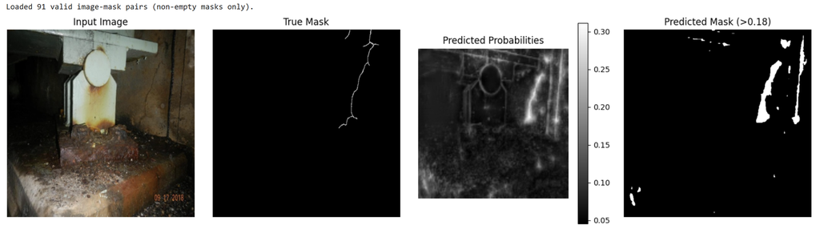

```python
visualize_segformer_prediction(model, test_dataset, threshold=0.18)
```

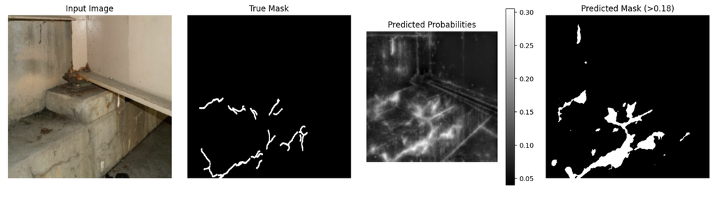

## Conclusion

In this notebook, we explored the initial steps toward building an automated crack detection system for buildings using drone imagery. We identified the key challenges related to dataset availability, including the need for diverse image angles, lighting conditions, and backgrounds. By analyzing existing datasets and preparing our data pipeline, we laid the groundwork for training models capable of distinguishing cracks from other surface features.

Regarding the segmentation part of the project, we further implemented and compared two types of deep learning models: a CNN-based U-Net with a ResNet encoder and a transformer-based SegFormer model. The U-Net architecture, known for its effectiveness in biomedical and segmentation tasks, was trained using a custom PyTorch pipeline with binary cross-entropy loss. It processes images with crack masks and learns to identify crack regions through pixel-wise binary classification. U-Net performs well on structured tasks and benefits from its simplicity and strong local feature extraction, but it may struggle with capturing long-range dependencies in complex patterns.

To address this, we introduced SegFormer, a modern transformer-based model that excels at learning global context in images. Using Hugging Face’s Trainer API, we fine-tuned a pretrained SegFormer model on the same crack dataset, adapting it for binary segmentation with label-based training. This model is more robust for challenging segmentation cases where cracks are faint, thin, or spread across varying textures. By evaluating both models using Dice score and IoU metrics, along with visual inspection, we demonstrated how traditional and transformer-based approaches perform on the same task. This comparison highlights the strengths of each architecture: U-Net is efficient and effective for simpler tasks, while SegFormer offers improved accuracy and context understanding in more complex segmentation scenarios.

To conclude, we worked on both classification and segmentation parts of the project. Due to the complex nature of the problem, we experimented a lot to try and find a solution. This last version of the notebook is containing our final results as fas we could go. Starting this, the project looked as it had no solution, but we are positive we did a lot and managed to deliver working models, although not perfect. Due to the lack of data for training, the models can be improved to suit more drone images. Overall, we are happy with the results and we achieved a lot during this time.